# Statistics — Complete Interview Notebook

| # | Topic | Link |
| --- | --- | --- |
| 1 | Foundations & Data Types | Go → |
| 2 | Descriptive Statistics | Go → |
| 3 | Probability Theory | Go → |
| 4 | Probability Distributions | Go → |
| 5 | Sampling & Estimation | Go → |
| 6 | Statistical Inference | Go → |
| 7 | Hypothesis Tests | Go → |
| 8 | Correlation & Covariance | Go → |
| 9 | Regression | Go → |
| 10 | Model Evaluation | Go → |
| 11 | Bayesian Statistics | Go → |
| 12 | Data Exploration & Preparation | Go → |
| 13 | Simulation & Optimization | Go → |
| 14 | Multivariate & Advanced Topics | Go → |
| 15 | Predictive Modeling Concepts | Go → |
| 16 | Business Analytics | Go → |
| 17 | Scenario-Based Interview Questions (510+) | Go → |

### Part 1: Foundations & Data Types

Statistics is the science of collecting, organizing, analyzing, interpreting, and presenting data. Every data science interview starts here — these fundamentals underpin every technique that follows.

#### What is Statistics?

| Branch | Purpose | Example |
| --- | --- | --- |
| **Descriptive** | Summarize and describe data | Mean salary = $75K, median = $68K |
| **Inferential** | Draw conclusions about populations from samples | "With 95% confidence, average salary is between $70K-$80K" |
| **Predictive** | Forecast future outcomes using patterns | Churn model predicts 15% of users will leave |
| **Prescriptive** | Recommend actions based on analysis | "Offer 20% discount to high-risk churn users" |

#### Types of Data

| Type | Description | Examples | Operations |
| --- | --- | --- | --- |
| **Qualitative (Categorical)** | Describes categories or groups | Color, Gender, City | Frequency, Mode |
| **Quantitative (Numerical)** | Describes measurable quantities | Height, Revenue, Age | Mean, Variance, Regression |

**Quantitative subdivides into:**

| Subtype | Description | Examples |
| --- | --- | --- |
| **Discrete** | Countable, finite values | Number of orders (0, 1, 2…), dice rolls |
| **Continuous** | Infinite values in a range | Temperature (36.7°C), time (2.345s) |

#### Scales of Measurement (S.T.I.R.)

| Scale | Properties | Examples | Allowed Operations |
| --- | --- | --- | --- |
| **Nominal** | Categories only, no order | Blood type (A, B, O), Country | Mode, frequency, chi-square |
| **Ordinal** | Categories with order, unequal intervals | Education (HS < BS < MS), Rating (1-5) | Median, percentile, rank correlation |
| **Interval** | Ordered, equal intervals, no true zero | Temperature (°C), IQ score, Year | Mean, SD, Pearson correlation |
| **Ratio** | Interval + true zero | Height, Weight, Income, Age | All operations + geometric mean |

> **Interview Tip:** "Can you multiply or divide meaningfully?" → **Ratio**. "Is zero meaningful?" → if yes, **Ratio**; if no, **Interval**.

#### Population vs Sample

|  | Population | Sample |
| --- | --- | --- |
| **Definition** | Entire group of interest | Subset selected from population |
| **Size notation** | $N$ | $n$ |
| **Mean symbol** | $\mu$ (mu) | $\bar{x}$ (x-bar) |
| **SD symbol** | $\sigma$ (sigma) | $s$ |
| **Variance divisor** | $N$ | $n - 1$ (Bessel's correction) |
| **Feasibility** | Often impractical to measure | Practical and cost-effective |

**Why $n-1$ for sample variance?** Bessel's correction compensates for the bias in estimating population variance from a sample. Using $n$ would systematically underestimate the true variance.

#### Parameter vs Statistic

|  | Parameter | Statistic |
| --- | --- | --- |
| **Describes** | Population | Sample |
| **Value** | Fixed (usually unknown) | Varies by sample |
| **Symbol** | Greek (μ, σ, π) | Latin ($\bar{x}$, $s$, $\hat{p}$) |
| **Example** | True mean height of all adults | Mean height from a survey of 500 adults |

#### Data Types in Analytics

| Data Type | Description | Examples | Common Encoding |
| --- | --- | --- | --- |
| **Structured** | Organized in rows/columns with schema | SQL tables, CSV, Excel | Direct use |
| **Unstructured** | No predefined format | Images, text, audio, video | Embedding, feature extraction |
| **Semi-structured** | Some structure, flexible schema | JSON, XML, logs | Parsing + flattening |
| **Time-series** | Sequential observations over time | Stock prices, sensor data | Lag features, rolling stats |
| **Cross-sectional** | Observations at single point in time | Survey responses, census snapshot | Standard tabular |
| **Panel (Longitudinal)** | Cross-sectional + time-series combined | Same users tracked over months | Fixed/random effects |

#### Foundations — Interview Questions

| # | Question | Answer |
| --- | --- | --- |
| 1 | Difference between descriptive and inferential statistics? | • Descriptive: summarize data (mean, charts, tables) • Inferential: draw conclusions about population from sample • Example: mean salary (descriptive) vs. confidence interval for population mean (infe… |
| 2 | What are the four scales of measurement? | • **Nominal**: categories, no order (color, country) • **Ordinal**: categories with order (rating 1-5) • **Interval**: equal spacing, no true zero (temperature °C) • **Ratio**: equal spacing + true ze… |
| 3 | Why do we use $n-1$ instead of $n$ for sample variance? | • Bessel's correction: dividing by $n$ underestimates population variance • Sample mean is estimated, not exact → lose 1 degree of freedom • $n-1$ gives an **unbiased** estimator of $\sigma^2$ |
| 4 | Give an example where mean is misleading. | • Income data: [30K, 35K, 40K, 45K, 500K] → mean = 130K (skewed by outlier) • Median = 40K is more representative • Always report both + check for skewness |
| 5 | Structured vs unstructured data? | • Structured: fixed schema, rows/columns (SQL table, CSV) • Unstructured: no schema (text, images, audio) • Semi-structured: flexible schema (JSON, XML) • 80-90% of world's data is unstructured |
| 6 | What is a random variable? | • A function that maps outcomes to real numbers • Discrete RV: countable outcomes (coin flips → 0, 1) • Continuous RV: uncountable outcomes (height → any real number) • Notation: $X$ for variable, $x$… |
| 7 | Explain cross-sectional vs time-series vs panel data. | • Cross-sectional: many subjects, one time point (survey) • Time-series: one subject, many time points (stock price) • Panel: many subjects across many time points (user activity monthly) • Panel data… |
| 8 | What is a degree of freedom? | • Number of independent values that can vary in a calculation • For sample variance: $df = n - 1$ (one value fixed by mean) • For chi-square test: $df = (rows-1)(cols-1)$ • More df → t-distribution ap… |
| 9 | Nominal vs ordinal — give 3 examples each. | • Nominal: blood type (A/B/O), color (red/blue), city (NYC/LA) • Ordinal: education (HS < BS < MS), satisfaction (low < med < high), rank (1st, 2nd, 3rd) • Key: ordinals have order but unequal gaps be… |
| 10 | What is the difference between a parameter and a statistic? | • Parameter: describes population (μ, σ), fixed but usually unknown • Statistic: describes sample ($\bar{x}$, $s$), varies by sample • Statistics are used to estimate parameters • Example: survey mean… |
| 11 | What does 'representative sample' mean? | • Sample that mirrors the population's key characteristics • Achieved through: random sampling, stratification, sufficient size • Non-representative → selection bias → wrong conclusions • Example: sur… |
| 12 | What is the Law of Large Numbers? | • As sample size increases, sample mean converges to population mean • Formal: $\bar{X}_n \xrightarrow{P} \mu$ as $n \to \infty$ • Weak LLN: convergence in probability • Practical: larger samples = mo… |
| 13 | Continuous vs discrete — how does it affect analysis? | • Discrete: use PMF, count-based tests (chi-square, binomial) • Continuous: use PDF, measurement-based tests (t-test, ANOVA) • Continuous can be discretized (binning); discrete treated as continuous i… |
| 14 | What is an observational study vs experiment? | • Observational: measure without intervention (survey, cohort study) • Experiment: manipulate treatment, control confounders (RCT) • Only experiments can establish causation • Observational: risk of c… |
| 15 | What is Simpson's Paradox? | • Trend in aggregated data reverses when split by subgroups • Example: Drug A has higher success overall, but Drug B wins in every subgroup • Caused by lurking confounding variable • Resolution: segme… |
| 16 | What does independent and identically distributed (i.i.d.) mean? | • Independent: knowing one observation tells nothing about another • Identically distributed: all observations come from same distribution • Assumption of most classical statistical tests • Violations… |
| 17 | Ratio vs interval scale — key difference with example? | • Interval: no true zero (0°C doesn't mean no temperature) • Ratio: true zero exists (0 kg = no weight) • Test: is "twice" meaningful? 100 kg = 2 × 50 kg ✓ (ratio); 100°C ≠ 2× as hot as 50°C ✗ (interv… |
| 18 | What is ecological fallacy? | • Inferring individual-level conclusions from group-level data • Example: a state with high income has low crime, but it doesn't mean rich individuals commit less crime • Opposite: atomistic fallacy (… |
| 19 | What is survivorship bias? | • Analyzing only 'survivors' and ignoring those that dropped out • Example: studying successful companies to find success factors — ignoring failed companies with same traits • Leads to overly optimis… |
| 20 | What is the difference between accuracy and precision in measurement? | • Accuracy: closeness to true value (low bias) • Precision: consistency of repeated measurements (low variance) • High accuracy + low precision: scattered around target • Both needed: accurate + preci… |

### Part 2: Descriptive Statistics

Descriptive statistics condense large datasets into meaningful summaries. They are the first step in any analysis and the most frequently tested topic in interviews.

#### Measures of Central Tendency

| Measure | Formula | When to Use | Sensitive to Outliers? |
| --- | --- | --- | --- |
| **Mean** | $\bar{x} = \frac{\sum_{i=1}^{n} x_i}{n}$ | Symmetric data, no extreme outliers | ✅ Yes |
| **Median** | Middle value when sorted | Skewed data, ordinal data | ❌ No |
| **Mode** | Most frequent value | Categorical data, multimodal distributions | ❌ No |
| **Weighted Mean** | $\bar{x}_w = \frac{\sum w_i x_i}{\sum w_i}$ | Values have different importance | ✅ Yes |
| **Trimmed Mean** | Mean after removing top/bottom k% | Robust alternative to mean | Partially |
| **Geometric Mean** | $\left(\prod_{i=1}^{n} x_i\right)^{1/n}$ | Growth rates, ratios, percentages | ✅ Yes |
| **Harmonic Mean** | $\frac{n}{\sum \frac{1}{x_i}}$ | Rates, speeds, price-earnings ratios | ✅ Yes |

**Relationship in skewed data:**

- **Right-skewed** (positive): Mode < Median < Mean
- **Left-skewed** (negative): Mean < Median < Mode
- **Symmetric**: Mean ≈ Median ≈ Mode

```python
import numpy as np
from scipy import stats

data = [23, 25, 27, 28, 30, 31, 33, 35, 100]  # right-skewed

print(f'Mean:   {np.mean(data):.2f}')           # 36.89 — pulled by outlier
print(f'Median: {np.median(data):.2f}')          # 30.00 — robust
print(f'Mode:   {stats.mode(data).mode}')        # no repeated value
print(f'Trimmed Mean (10%): {stats.trim_mean(data, 0.1):.2f}')  # removes extremes
```

```
Mean:   36.89
Median: 30.00
Mode:   23
Trimmed Mean (10%): 36.89
```

#### Measures of Dispersion (Spread)

| Measure | Formula | Description |
| --- | --- | --- |
| **Range** | $\max - \min$ | Simplest spread measure; sensitive to outliers |
| **Variance** | $\sigma^2 = \frac{\sum(x_i - \mu)^2}{N}$ (pop) or $s^2 = \frac{\sum(x_i - \bar{x})^2}{n-1}$ (sample) | Average squared deviation from mean |
| **Standard Deviation** | $\sigma = \sqrt{\sigma^2}$ or $s = \sqrt{s^2}$ | Same units as data; most common spread measure |
| **IQR** | $Q3 - Q1$ | Range of middle 50%; robust to outliers |
| **MAD** | $\text{median}(\vert x_i - \text{median}(x)\mid )$ | Median Absolute Deviation; very robust |
| **Coefficient of Variation** | $CV = \frac{s}{\bar{x}} \times 100\%$ | Relative variability; compare across different scales |

```python
data = [12, 15, 18, 22, 25, 28, 30, 35, 40, 120]

print(f'Range:     {np.ptp(data)}')                    # 108
print(f'Variance:  {np.var(data, ddof=1):.2f}')        # sample variance
print(f'Std Dev:   {np.std(data, ddof=1):.2f}')        # sample SD
q1, q3 = np.percentile(data, [25, 75])
print(f'IQR:       {q3 - q1:.2f}')                     # robust spread
print(f'CV:        {np.std(data, ddof=1)/np.mean(data)*100:.1f}%')  # relative
```

```
Range:     108
Variance:  978.72
Std Dev:   31.28
IQR:       14.75
CV:        90.7%
```

#### Percentiles & Quartiles

| Term | Definition |
| --- | --- |
| **P-th Percentile** | Value below which P% of data falls |
| **Q1 (25th percentile)** | Lower quartile — 25% of data is below |
| **Q2 (50th percentile)** | Median — 50% below |
| **Q3 (75th percentile)** | Upper quartile — 75% below |
| **IQR** | $Q3 - Q1$ — contains middle 50% of data |
| **Outlier (IQR method)** | Any point < $Q1 - 1.5 \times IQR$ or > $Q3 + 1.5 \times IQR$ |

```python
data = np.array([2, 5, 7, 8, 10, 12, 15, 18, 22, 50])

q1, q2, q3 = np.percentile(data, [25, 50, 75])
iqr = q3 - q1
lower_fence = q1 - 1.5 * iqr
upper_fence = q3 + 1.5 * iqr
outliers = data[(data < lower_fence) | (data > upper_fence)]

print(f'Q1={q1}, Q2={q2}, Q3={q3}, IQR={iqr}')
print(f'Fences: [{lower_fence:.1f}, {upper_fence:.1f}]')
print(f'Outliers: {outliers}')  # [50]
```

```
Q1=7.25, Q2=11.0, Q3=17.25, IQR=10.0
Fences: [-7.8, 32.2]
Outliers: [50]
```

#### Skewness

Skewness measures the **asymmetry** of a distribution around its mean.

$$\text{Skewness} = \frac{\frac{1}{n}\sum_{i=1}^n (x_i - \bar{x})^3}{s^3}$$

| Skewness Value | Shape | Tail Direction | Example |
| --- | --- | --- | --- |
| **= 0** | Symmetric | Neither | Normal distribution, heights |
| **> 0** (positive) | Right-skewed | Long right tail | Income, house prices |
| **< 0** (negative) | Left-skewed | Long left tail | Age at retirement, exam scores (easy test) |

```python
from scipy.stats import skew, kurtosis

normal_data = np.random.normal(50, 10, 1000)
skewed_data = np.random.exponential(5, 1000)  # right-skewed

print(f'Normal skewness:  {skew(normal_data):.3f}')   # ≈ 0
print(f'Exponential skew: {skew(skewed_data):.3f}')   # ≈ 2.0 (positive)
```

```
Normal skewness:  -0.033
Exponential skew: 1.868
```

> **Interview Tip:** In right-skewed data, mean > median. Use median or log-transform for better analysis.

#### Kurtosis

Kurtosis measures the **tailedness** of a distribution — how heavy the tails are compared to a normal distribution.

$$\text{Kurtosis} = \frac{\frac{1}{n}\sum_{i=1}^n (x_i - \bar{x})^4}{s^4}$$

| Type | Excess Kurtosis | Description | Example |
| --- | --- | --- | --- |
| **Mesokurtic** | ≈ 0 | Normal-like tails | Normal distribution |
| **Leptokurtic** | > 0 | Heavy tails, sharp peak, more outliers | Financial returns, t-distribution |
| **Platykurtic** | < 0 | Light tails, flat peak, fewer outliers | Uniform distribution |

> **Note:** `scipy.stats.kurtosis()` returns **excess kurtosis** (kurtosis − 3) by default, where 0 = normal.

```python
print(f'Normal kurtosis:      {kurtosis(normal_data):.3f}')       # ≈ 0
print(f'Exponential kurtosis: {kurtosis(skewed_data):.3f}')       # > 0 (heavy tails)
print(f'Uniform kurtosis:     {kurtosis(np.random.uniform(0,1,1000)):.3f}')  # < 0
```

```
Normal kurtosis:      -0.039
Exponential kurtosis: 5.117
Uniform kurtosis:     -1.179
```

#### Five-Number Summary & Box Plot

The **five-number summary** = {Min, Q1, Median, Q3, Max} provides a complete snapshot of data distribution.

```
         ┌─────────────────┐
    ○────┤       ┃         ├────○
         └─────────────────┘
  outlier  Q1    Median   Q3   outlier
         ├───── IQR ──────┤
```

```python
data = [5, 7, 8, 12, 14, 18, 22, 25, 30, 100]

summary = np.percentile(data, [0, 25, 50, 75, 100])
print(f'Min={summary[0]}, Q1={summary[1]}, Median={summary[2]}, Q3={summary[3]}, Max={summary[4]}')
```

```
Min=5.0, Q1=9.0, Median=16.0, Q3=24.25, Max=100.0
```

#### Empirical Rule (68-95-99.7)

For **normally distributed** data:

| Range | % of Data |
| --- | --- |
| $\mu \pm 1\sigma$ | 68% |
| $\mu \pm 2\sigma$ | 95% |
| $\mu \pm 3\sigma$ | 99.7% |

> Any value beyond $3\sigma$ from the mean is extremely rare (~0.3%) and often considered an outlier.

#### Z-Score (Standard Score)

Converts any value to the number of standard deviations from the mean:

$$z = \frac{x - \mu}{\sigma}$$

[output not shown]

```python
value, mean, std = 85, 70, 10
z_score = (value - mean) / std
print(f'Z-score: {z_score}')  # 1.5 → 1.5 std devs above mean

# Z-score for entire array
data = np.array([55, 60, 65, 70, 75, 80, 85])
z_scores = (data - np.mean(data)) / np.std(data, ddof=1)
print(f'Z-scores: {np.round(z_scores, 2)}')
```

```
Z-score: 1.5
Z-scores: [-1.39 -0.93 -0.46  0.    0.46  0.93  1.39]
```

#### Descriptive Statistics — Interview Questions

| # | Question | Answer |
| --- | --- | --- |
| 1 | When would you use median over mean? | • Skewed data (income, house prices, response times) • Outliers present that inflate/deflate mean • Ordinal data where arithmetic mean isn't meaningful • Rule: if mean and median differ significantly … |
| 2 | Explain variance vs standard deviation. | • Variance ($s^2$): average squared deviations — in squared units • SD ($s$): square root of variance — in original units • SD is more interpretable (same scale as data) • Variance is used in many for… |
| 3 | What is the coefficient of variation? When is it useful? | • $CV = (s / \bar{x}) \times 100\%$ — relative variability • Useful for comparing variability across different scales • Example: compare salary spread ($\bar{x}$=80K, s=10K, CV=12.5%) vs age ($\bar{x}… |
| 4 | How do you identify outliers? | • **Z-score method**: $\vert z\vert > 3$ (assumes normality) • **IQR method**: below $Q1 - 1.5 \times IQR$ or above $Q3 + 1.5 \times IQR$ • **Visual**: box plot whiskers, scatter plots • **Domain know… |
| 5 | Explain positive vs negative skewness with real examples. | • **Positive (right)**: long right tail — income, wealth, website traffic • Mean > Median; few extreme high values pull mean right • **Negative (left)**: long left tail — age at death, easy exam score… |
| 6 | What does high kurtosis tell you? | • Heavy tails → more extreme values than normal distribution • Leptokurtic: sharp peak, fat tails (financial returns often have this) • Means higher probability of outliers • Important for risk modeli… |
| 7 | Explain the empirical rule. When can you use it? | • 68-95-99.7 rule for normal distributions • 68% within ±1σ, 95% within ±2σ, 99.7% within ±3σ • Only applies to approximately normal (bell-shaped) data • Quick sanity check: value 4σ from mean is extr… |
| 8 | What is a z-score and when do you use it? | • $z = (x - \mu) / \sigma$ — number of SDs from mean • Standardization: compare values from different distributions • Outlier detection: $\vert z\vert > 3$ is unusual • Prerequisite: meaningful for sy… |
| 9 | Geometric mean vs arithmetic mean? | • Arithmetic: sum/n — for additive quantities (heights, temperatures) • Geometric: nth root of product — for multiplicative quantities (growth rates, returns) • Example: investments returning +50%, -5… |
| 10 | How do you summarize a dataset for a non-technical stakeholder? | • Report: count, mean/median, range, key percentiles • Use visualizations: histograms, box plots • Highlight: distribution shape (skewed?), outliers, notable patterns • Always relate to business conte… |
| 11 | What is the difference between MAD and standard deviation? | • MAD (Median Absolute Deviation): median of absolute deviations from median • SD: root mean squared deviation from mean • MAD is much more robust to outliers (breakdown point 50%) • Use MAD when data… |
| 12 | Explain the five-number summary. | • Min, Q1, Median (Q2), Q3, Max • Box plot visualizes this: box = IQR, line = median, whiskers = range • Robust: not affected by outliers (unlike mean and SD) • Gives full picture: center, spread, sym… |
| 13 | Why is range a poor measure of spread? | • Uses only min and max → extremely sensitive to outliers • One extreme value completely changes range • Ignores all data between min and max • Better alternatives: IQR (robust) or SD (most used) |
| 14 | How does sample size affect standard error? | • $SE = s / \sqrt{n}$ — decreases as n increases • More data → more precision in estimating the mean • To halve the SE, quadruple the sample size • SE is different from SD: SD measures spread, SE meas… |
| 15 | What happens when you add a constant to all data points? | • Mean shifts by that constant: $\bar{x}_{new} = \bar{x} + c$ • Median also shifts by $c$ • Variance, SD, IQR remain **unchanged** • Shape of distribution is identical (just shifted) |
| 16 | What happens when you multiply all data points by a constant? | • Mean multiplied: $\bar{x}_{new} = c \cdot \bar{x}$ • Median multiplied: $\text{Med}_{new} = c \cdot \text{Med}$ • Variance multiplied by $c^2$: $s^2_{new} = c^2 \cdot s^2$ • SD multiplied by $\vert … |
| 17 | You have two datasets with same mean but different SDs. What does this tell you? | • Same center but different spread • Higher SD → more variability, less consistency • Example: students in class A (mean=75, SD=5) are more consistent than class B (mean=75, SD=15) • For decision-maki… |
| 18 | How would you describe a bimodal distribution? | • Distribution with two distinct peaks (modes) • Suggests two subpopulations in the data • Example: height distribution for mixed male+female group • Action: consider splitting into subgroups for anal… |
| 19 | Difference between standard error and standard deviation? | • SD: spread of individual observations ($s$) • SE: spread of the sample mean estimator ($s/\sqrt{n}$) • SD describes data; SE describes precision of estimate • SE always ≤ SD; SE → 0 as n → ∞ |
| 20 | How do you handle skewed data for analysis? | • Log transform: common for right-skewed data (income, prices) • Square root: moderate skew reduction • Box-Cox: automated power transformation • Use non-parametric methods (median, rank tests) • Or u… |
| 21 | Explain Chebyshev's inequality. | • For any distribution: at least $1 - 1/k^2$ of data lies within $k$ SDs of mean • $k=2$: at least 75% within 2σ; $k=3$: at least 89% • Works for ANY shape — unlike empirical rule (normal only) • Cons… |
| 22 | What is a robust statistic? | • Statistic that isn't heavily influenced by outliers or non-normality • Examples: median (vs mean), IQR (vs range), MAD (vs SD), trimmed mean • Breakdown point: % of data that can be extreme before s… |
| 23 | When to use weighted mean? Give an example. | • When observations have different importance or reliability • GPA: subjects have different credits → $\bar{x}_w = \sum(\text{grade} \times \text{credits}) / \sum(\text{credits})$ • Weighted survey: a… |
| 24 | You are given a dataset. Walk through your EDA process. | • 1. Shape: check dimensions, data types, head/tail • 2. Summarize: mean, median, SD, quartiles per column • 3. Missing: count nulls, decide imputation strategy • 4. Distributions: histograms, box plo… |
| 25 | How would you explain the box plot to a stakeholder? | • The box shows where the middle 50% of data falls (Q1 to Q3) • The line inside is the median — half above, half below • Whiskers show the full range excluding outliers • Dots beyond whiskers are outl… |

#### Statistical Visualizations — Interview Essentials

These are the most commonly asked plots in statistics interviews. You should know when to use each:

| Plot | Purpose | When to Use |
| --- | --- | --- |
| **Boxplot** | Show median, IQR, outliers | Comparing distributions, detecting outliers |
| **Histogram + KDE** | Show distribution shape | Understanding data distribution |
| **QQ-Plot** | Test normality assumption | Before parametric tests (t-test, ANOVA) |
| **Violin Plot** | Distribution shape + density | Richer alternative to boxplot |
| **Normal curve (68-95-99.7)** | Empirical rule | Explaining standard deviations |

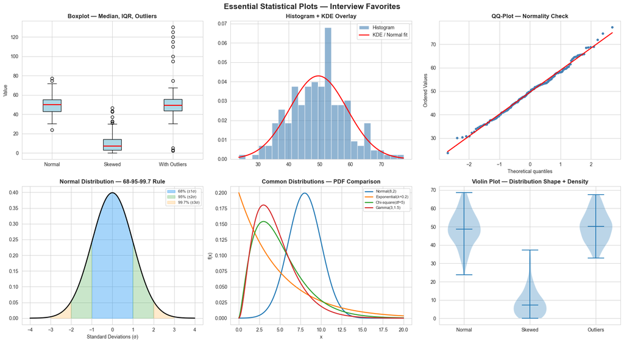

```
Key interview takeaway: Always visualize your data FIRST before any analysis!
```

```python
# ──────────────────────────────────────────────
# Statistical Visualizations — Most Asked in Interviews
# ──────────────────────────────────────────────
import numpy as np
import matplotlib.pyplot as plt
import seaborn as sns
from scipy import stats

np.random.seed(42)
sns.set_style('whitegrid')

# Generate sample data
normal_data = np.random.normal(loc=50, scale=10, size=200)
skewed_data = np.random.exponential(scale=10, size=200)
data_with_outliers = np.concatenate([np.random.normal(50, 8, 190), [95, 100, 110, 5, 3, 115, 120, 2, 125, 130]])

fig, axes = plt.subplots(2, 3, figsize=(18, 10))
fig.suptitle('Essential Statistical Plots — Interview Favorites', fontsize=16, fontweight='bold')

# 1. Boxplot — shows median, quartiles, outliers
ax = axes[0, 0]
bp = ax.boxplot([normal_data, skewed_data, data_with_outliers],
                labels=['Normal', 'Skewed', 'With Outliers'],
                patch_artist=True,
                boxprops=dict(facecolor='lightblue'),
                medianprops=dict(color='red', linewidth=2))
ax.set_title('Boxplot — Median, IQR, Outliers', fontweight='bold')
ax.set_ylabel('Value')

# 2. Histogram + KDE — distribution shape
ax = axes[0, 1]
ax.hist(normal_data, bins=25, density=True, alpha=0.6, color='steelblue', edgecolor='white', label='Histogram')
x = np.linspace(normal_data.min(), normal_data.max(), 100)
ax.plot(x, stats.norm.pdf(x, normal_data.mean(), normal_data.std()),
        'r-', linewidth=2, label='KDE / Normal fit')
ax.set_title('Histogram + KDE Overlay', fontweight='bold')
ax.legend()

# 3. QQ-Plot — normality test
ax = axes[0, 2]
stats.probplot(normal_data, dist='norm', plot=ax)
ax.set_title('QQ-Plot — Normality Check', fontweight='bold')
ax.get_lines()[0].set(color='steelblue', markersize=4)
ax.get_lines()[1].set(color='red', linewidth=2)

# 4. Normal Distribution — shaded areas (68-95-99.7 rule)
ax = axes[1, 0]
x = np.linspace(-4, 4, 500)
y = stats.norm.pdf(x)
ax.plot(x, y, 'k-', linewidth=2)
ax.fill_between(x, y, where=(x >= -1) & (x <= 1), alpha=0.4, color='#2196F3', label='68% (±1σ)')
ax.fill_between(x, y, where=((x >= -2) & (x < -1)) | ((x > 1) & (x <= 2)), alpha=0.3, color='#4CAF50', label='95% (±2σ)')
ax.fill_between(x, y, where=((x >= -3) & (x < -2)) | ((x > 2) & (x <= 3)), alpha=0.2, color='#FF9800', label='99.7% (±3σ)')
ax.set_title('Normal Distribution — 68-95-99.7 Rule', fontweight='bold')
ax.legend(fontsize=8)
ax.set_xlabel('Standard Deviations (σ)')

# 5. Distribution Comparison — PDF overlay
ax = axes[1, 1]
x = np.linspace(0, 20, 200)
ax.plot(x, stats.norm.pdf(x, 8, 2), linewidth=2, label='Normal(8,2)')
ax.plot(x, stats.expon.pdf(x, scale=5), linewidth=2, label='Exponential(λ=0.2)')
ax.plot(x, stats.chi2.pdf(x, df=5), linewidth=2, label='Chi-square(df=5)')
ax.plot(x, stats.gamma.pdf(x, a=3, scale=1.5), linewidth=2, label='Gamma(3,1.5)')
ax.set_title('Common Distributions — PDF Comparison', fontweight='bold')
ax.legend(fontsize=8)
ax.set_xlabel('x')
ax.set_ylabel('f(x)')

# 6. Violin Plot — distribution + boxplot combined
ax = axes[1, 2]
import pandas as pd
df_violin = pd.DataFrame({
    'Normal': normal_data[:100],
    'Skewed': skewed_data[:100],
    'Outliers': data_with_outliers[:100]
})
parts = ax.violinplot([normal_data[:100], skewed_data[:100], data_with_outliers[:100]],
                       positions=[1,2,3], showmedians=True, showextrema=True)
ax.set_xticks([1,2,3])
ax.set_xticklabels(['Normal', 'Skewed', 'Outliers'])
ax.set_title('Violin Plot — Distribution Shape + Density', fontweight='bold')

plt.tight_layout()
plt.show()
print('Key interview takeaway: Always visualize your data FIRST before any analysis!')
```

### Part 3: Probability Theory

Probability is the mathematical language of uncertainty. Every statistical inference, every ML model, and every A/B test rests on probability.

#### Core Definitions

| Term | Definition | Example |
| --- | --- | --- |
| **Experiment** | Process that generates outcomes | Rolling a die |
| **Sample Space (S)** | Set of all possible outcomes | S = {1, 2, 3, 4, 5, 6} |
| **Event (A)** | Subset of sample space | A = {even} = {2, 4, 6} |
| **Probability P(A)** | Measure of likelihood, 0 ≤ P(A) ≤ 1 | P(even) = 3/6 = 0.5 |
| **Complement (A')** | Everything not in A | P(A') = 1 − P(A) |

#### Probability Rules

| Rule | Formula | When to Use |
| --- | --- | --- |
| **Addition (OR)** | $P(A \cup B) = P(A) + P(B) - P(A \cap B)$ | Either event occurs |
| **Mutually Exclusive** | $P(A \cup B) = P(A) + P(B)$ | Events can't happen together |
| **Multiplication (AND)** | $P(A \cap B) = P(A) \cdot P(B\mid A)$ | Both events occur |
| **Independent Events** | $P(A \cap B) = P(A) \cdot P(B)$ | One event doesn't affect the other |
| **Complement** | $P(A') = 1 - P(A)$ | Probability of NOT A |

#### Conditional Probability

The probability of A **given that** B has already occurred:

$$P(A\mid B) = \frac{P(A \cap B)}{P(B)}$$

**Example:** A bag has 5 red and 3 blue balls. Draw one ball (red), don't replace it. What's the probability the second ball is red?

$$P(\text{2nd red} \mid \text{1st red}) = \frac{4}{7} \approx 0.571$$

```python
# Conditional probability simulation
import numpy as np

n_simulations = 100_000
count = 0
for _ in range(n_simulations):
    bag = ['R']*5 + ['B']*3
    first = np.random.choice(bag)
    if first == 'R':
        bag.remove('R')
        second = np.random.choice(bag)
        if second == 'R':
            count += 1

# P(both red) via simulation
p_first_red = 5/8
p_both_red_sim = count / n_simulations
p_second_given_first = p_both_red_sim / p_first_red
print(f'P(2nd red | 1st red) ≈ {p_second_given_first:.3f}')  # ≈ 0.571
```

```
P(2nd red | 1st red) ≈ 0.568
```

#### Independence

Two events A and B are **independent** if knowing one tells you nothing about the other:

$$P(A\mid B) = P(A) \quad \text{or equivalently} \quad P(A \cap B) = P(A) \cdot P(B)$$

|  | Independent | Dependent |
| --- | --- | --- |
| **Example** | Two coin flips | Drawing cards without replacement |
| **Joint prob** | $P(A \cap B) = P(A) \cdot P(B)$ | $P(A \cap B) = P(A) \cdot P(B\mid A)$ |
| **Key test** | Does $P(A\mid B) = P(A)$? | $P(A\mid B) \neq P(A)$ |

> **Common Mistake:** Independent ≠ mutually exclusive. Mutually exclusive events are actually **dependent** (if one occurs, the other cannot).

#### Law of Total Probability

If $B_1, B_2, \ldots, B_n$ are mutually exclusive and exhaustive partitions of the sample space:

$$P(A) = \sum_{i=1}^n P(A\mid B_i) \cdot P(B_i)$$

**Example:** A factory has 3 machines producing parts. Machine 1 makes 30% (2% defective), Machine 2 makes 45% (3% defective), Machine 3 makes 25% (5% defective). What's the overall defect rate?

$$P(\text{defect}) = 0.30 \times 0.02 + 0.45 \times 0.03 + 0.25 \times 0.05 = 0.032 = 3.2\%$$

#### Bayes' Theorem

The most important formula in data science — it lets you **update beliefs** with new evidence:

$$P(A\mid B) = \frac{P(B\mid A) \cdot P(A)}{P(B)}$$

| Term | Name | Meaning |
| --- | --- | --- |
| $P(A)$ | **Prior** | Initial belief before seeing evidence |
| $P(B\mid A)$ | **Likelihood** | Probability of evidence given hypothesis |
| $P(A\mid B)$ | **Posterior** | Updated belief after seeing evidence |
| $P(B)$ | **Evidence / Marginal** | Total probability of observing the data |

**Classic Example — Disease Testing:**

A test is 99% sensitive (true positive rate) and 95% specific (true negative rate). Disease prevalence is 1%. If a patient tests positive, what's the probability they actually have the disease?

$$P(\text{disease}\mid +) = \frac{P(+\mid \text{disease}) \cdot P(\text{disease})}{P(+)} = \frac{0.99 \times 0.01}{0.99 \times 0.01 + 0.05 \times 0.99} = \frac{0.0099}{0.0594} \approx 16.7\%$$

Even with a positive test, there's only a 16.7% chance of having the disease! The low prevalence (prior) dominates.

```python
# Bayes' theorem calculator
def bayes(prior, likelihood, false_positive_rate):
    evidence = likelihood * prior + false_positive_rate * (1 - prior)
    posterior = (likelihood * prior) / evidence
    return posterior

# Disease testing example
posterior = bayes(prior=0.01, likelihood=0.99, false_positive_rate=0.05)
print(f'P(disease | positive test) = {posterior:.3f}')  # 0.167

# What if prevalence is 10%?
posterior_high = bayes(prior=0.10, likelihood=0.99, false_positive_rate=0.05)
print(f'P(disease | +, prevalence=10%) = {posterior_high:.3f}')  # 0.688
```

```
P(disease | positive test) = 0.167
P(disease | +, prevalence=10%) = 0.688
```

#### Permutations & Combinations

| Concept | Formula | Order Matters? | Example |
| --- | --- | --- | --- |
| **Permutation** | $P(n,r) = \frac{n!}{(n-r)!}$ | ✅ Yes | Arranging 3 of 5 books: $\frac{5!}{2!} = 60$ |
| **Combination** | $C(n,r) = \binom{n}{r} = \frac{n!}{r!(n-r)!}$ | ❌ No | Choosing 3 of 5 people: $\binom{5}{3} = 10$ |

```python
from math import factorial, comb, perm

# How many ways to choose 3 people from 10 for a committee?
print(f'Combinations: {comb(10, 3)}')   # 120 (order doesn\'t matter)
print(f'Permutations: {perm(10, 3)}')   # 720 (order matters)
```

```
Combinations: 120
Permutations: 720
```

#### Probability — Interview Questions

[output not shown]

### Part 4: Probability Distributions

A distribution describes all possible values a random variable can take and their probabilities. Choosing the right distribution is fundamental to correct modeling.

#### Discrete Distributions

| Distribution | Notation | PMF | Mean | Variance | Use Case |
| --- | --- | --- | --- | --- | --- |
| **Bernoulli** | $X \sim \text{Bern}(p)$ | $P(X=1)=p, P(X=0)=1-p$ | $p$ | $p(1-p)$ | Single yes/no trial (click/no click) |
| **Binomial** | $X \sim B(n,p)$ | $\binom{n}{k}p^k(1-p)^{n-k}$ | $np$ | $np(1-p)$ | Number of successes in n trials |
| **Poisson** | $X \sim \text{Pois}(\lambda)$ | $\frac{\lambda^k e^{-\lambda}}{k!}$ | $\lambda$ | $\lambda$ | Count of events in fixed interval |
| **Geometric** | $X \sim \text{Geom}(p)$ | $(1-p)^{k-1}p$ | $1/p$ | $(1-p)/p^2$ | Trials until first success |
| **Negative Binomial** | $X \sim \text{NB}(r,p)$ | $\binom{k-1}{r-1}p^r(1-p)^{k-r}$ | $r/p$ | $r(1-p)/p^2$ | Trials until r-th success |
| **Hypergeometric** | $X \sim \text{HyperGeo}(N,K,n)$ | $\frac{\binom{K}{k}\binom{N-K}{n-k}}{\binom{N}{n}}$ | $nK/N$ | complex | Sampling without replacement |

```python
from scipy import stats
import numpy as np

# Bernoulli: single coin flip (p=0.7 biased coin)
bern = stats.bernoulli(p=0.7)
print(f'Bernoulli: E[X]={bern.mean()}, Var={bern.var()}')

# Binomial: 20 emails, 30% are spam. How many spam?
binom = stats.binom(n=20, p=0.3)
print(f'Binomial: E[X]={binom.mean()}, P(X=5)={binom.pmf(5):.4f}')
print(f'P(X >= 8) = {1 - binom.cdf(7):.4f}')  # at least 8 spam

# Poisson: avg 3 calls/hour. P(5 calls in next hour)?
pois = stats.poisson(mu=3)
print(f'Poisson: P(X=5)={pois.pmf(5):.4f}, P(X>=5)={1-pois.cdf(4):.4f}')
```

```
Bernoulli: E[X]=0.7, Var=0.21000000000000002
Binomial: E[X]=6.0, P(X=5)=0.1789
P(X >= 8) = 0.2277
Poisson: P(X=5)=0.1008, P(X>=5)=0.1847
```

#### Continuous Distributions

| Distribution | Notation | PDF | Mean | Variance | Use Case |
| --- | --- | --- | --- | --- | --- |
| **Uniform** | $X \sim U(a,b)$ | $\frac{1}{b-a}$ for $a \leq x \leq b$ | $\frac{a+b}{2}$ | $\frac{(b-a)^2}{12}$ | Equal probability (random number gen) |
| **Normal** | $X \sim N(\mu, \sigma^2)$ | $\frac{1}{\sigma\sqrt{2\pi}}e^{-\frac{(x-\mu)^2}{2\sigma^2}}$ | $\mu$ | $\sigma^2$ | Heights, errors, natural phenomena |
| **Standard Normal** | $Z \sim N(0, 1)$ | — | 0 | 1 | Z-scores, hypothesis testing |
| **Exponential** | $X \sim \text{Exp}(\lambda)$ | $\lambda e^{-\lambda x}$ | $1/\lambda$ | $1/\lambda^2$ | Time between events (wait times) |
| **Gamma** | $X \sim \Gamma(\alpha, \beta)$ | complex | $\alpha\beta$ | $\alpha\beta^2$ | Sum of exponentials, wait for α events |
| **Beta** | $X \sim \text{Beta}(\alpha, \beta)$ | complex | $\frac{\alpha}{\alpha+\beta}$ | complex | Probabilities, proportions, Bayesian prior |
| **Log-Normal** | $\ln(X) \sim N(\mu, \sigma^2)$ | complex | $e^{\mu+\sigma^2/2}$ | complex | Income, stock prices, particle sizes |
| **Chi-Square** | $X \sim \chi^2(k)$ | complex | $k$ | $2k$ | Goodness-of-fit, test independence |
| **Student's t** | $X \sim t(\nu)$ | complex | 0 (if ν>1) | $\frac{\nu}{\nu-2}$ | Small samples, unknown σ |
| **F-distribution** | $X \sim F(d_1, d_2)$ | complex | $\frac{d_2}{d_2-2}$ | complex | ANOVA, comparing variances |

```python
# Normal distribution
norm = stats.norm(loc=100, scale=15)  # IQ: mean=100, SD=15
print(f'P(IQ > 130) = {1 - norm.cdf(130):.4f}')        # ~0.0228 (top 2.3%)
print(f'P(85 < IQ < 115) = {norm.cdf(115) - norm.cdf(85):.4f}')  # ~0.6827
print(f'IQ at 95th percentile = {norm.ppf(0.95):.1f}')  # ~124.7

# Exponential: avg 10 min between bus arrivals
exp = stats.expon(scale=10)  # scale = 1/lambda = mean
print(f'P(wait > 15 min) = {1 - exp.cdf(15):.4f}')      # ~0.2231
print(f'Memoryless: P(wait > 25 | already waited 10) = P(wait > 15) = {1-exp.cdf(15):.4f}')
```

```
P(IQ > 130) = 0.0228
P(85 < IQ < 115) = 0.6827
IQ at 95th percentile = 124.7
P(wait > 15 min) = 0.2231
Memoryless: P(wait > 25 | already waited 10) = P(wait > 15) = 0.2231
```

#### The Normal Distribution — Deep Dive

The normal distribution is the most important distribution in statistics due to the **Central Limit Theorem**.

**Key properties:**

- Symmetric and bell-shaped around $\mu$
- Mean = Median = Mode at the center
- Fully defined by two parameters: $\mu$ (location) and $\sigma$ (scale)
- Area under curve = 1
- Tails extend to ±∞ but asymptotically approach 0

**Standard Normal Z-table critical values:**

| Confidence Level | Two-tailed $z^*$ | One-tailed $z^*$ |
| --- | --- | --- |
| 90% | 1.645 | 1.282 |
| 95% | 1.960 | 1.645 |
| 99% | 2.576 | 2.326 |

**When is data approximately normal?**

- Heights, weights, measurement errors
- Sample means (CLT, regardless of original distribution)
- NOT: income, counts, durations, proportions near 0 or 1

#### Choosing the Right Distribution

| Data Type / Scenario | Distribution | Why |
| --- | --- | --- |
| Yes/No outcome | Bernoulli | Binary result |
| # Successes in n trials | Binomial | Fixed n, fixed p |
| # Events in time/space | Poisson | Rare events, known rate |
| Time between events | Exponential | Memoryless waiting |
| Measurement with errors | Normal | Sum of many small effects (CLT) |
| Right-skewed positive values | Log-Normal | Product of many factors |
| Proportions / probabilities | Beta | Bounded [0,1], Bayesian prior |
| Sample mean difference | t-distribution | Unknown σ, small n |
| Sum of squared normals | Chi-Square | Test independence/fit |
| Ratio of variances | F-distribution | ANOVA, regression F-test |

#### Expectation & Variance Properties

| Property | Formula | Condition |
| --- | --- | --- |
| Linearity of E | $E[aX + b] = aE[X] + b$ | Always |
| E of sum | $E[X + Y] = E[X] + E[Y]$ | Always (even if dependent) |
| E of product | $E[XY] = E[X] \cdot E[Y]$ | Only if X, Y independent |
| Var scaling | $\text{Var}(aX + b) = a^2 \text{Var}(X)$ | Always |
| Var of sum | $\text{Var}(X+Y) = \text{Var}(X) + \text{Var}(Y)$ | Only if X, Y independent |
| Var of sum (general) | $\text{Var}(X+Y) = \text{Var}(X) + \text{Var}(Y) + 2\text{Cov}(X,Y)$ | Always |

#### Probability Distributions — Interview Questions

| # | Question | Answer |
| --- | --- | --- |
| 1 | When do you use Binomial vs Poisson? | • Binomial: fixed n trials, P(k successes) — 20 emails, how many spam? • Poisson: events in continuous interval, no fixed n — how many calls per hour? • Poisson approximates Binomial when n large, p s… |
| 2 | What is the memoryless property? Which distributions have it? | • $P(X > s+t \mid X > s) = P(X > t)$ — past doesn't affect future • Exponential (continuous) and Geometric (discrete) only • Example: if avg bulb life = 1000h, given it lasted 800h, expected remaining… |
| 3 | Why is the normal distribution so important? | • CLT: sample means converge to normal regardless of original distribution • Many natural phenomena are approximately normal (additive effects) • Mathematical convenience: closed-form properties • Fou… |
| 4 | Explain the difference between normal and log-normal. | • Normal: symmetric, can be negative, additive processes • Log-normal: right-skewed, always positive, multiplicative processes • $X \sim \text{LogNormal}$ means $\ln(X) \sim \text{Normal}$ • Examples:… |
| 5 | What is the Beta distribution and when would you use it? | • Distribution over probabilities [0, 1] • Parameterized by α (successes + 1) and β (failures + 1) • Used as prior in Bayesian inference for probabilities • Example: model click-through rate uncertain… |
| 6 | A website gets avg 5 signups/hour. P(0 signups in next hour)? | • Poisson with λ=5: $P(X=0) = e^{-5} \cdot 5^0 / 0! = e^{-5} \approx 0.0067$ • Less than 1% chance of zero signups • Assumptions: events independent, constant rate, no clustering • If rate varies by h… |
| 7 | What distribution would you use for time-to-event data? | • Exponential: constant hazard rate (memoryless) • Weibull: flexible hazard (increasing, decreasing, or constant) • Log-normal: common for repair times, claim amounts • Cox proportional hazards: regre… |
| 8 | What is the t-distribution? When does it differ from normal? | • Heavier tails than normal → accounts for extra uncertainty • Used when: population σ unknown AND small sample size • Parameter: degrees of freedom (ν = n − 1) • As ν → ∞, t → normal (at ν ≈ 30, near… |
| 9 | What is the chi-square distribution used for? | • Goodness of fit: does data match expected distribution? • Test of independence: are two categorical variables related? • Sum of squared standard normals: $\chi^2_k = Z_1^2 + \ldots + Z_k^2$ • Varian… |
| 10 | Explain the F-distribution. | • Ratio of two chi-square distributions (each divided by df) • ANOVA: compare variance between groups vs within groups • Regression: overall model significance (F-test) • Always ≥ 0; right-skewed; app… |
| 11 | What is the relationship between Bernoulli and Binomial? | • Bernoulli is Binomial with n=1 • Binomial = sum of n independent Bernoulli trials • $X \sim \text{Bin}(n,p) = X_1 + X_2 + \ldots + X_n$ where $X_i \sim \text{Bern}(p)$ • Example: each click is Berno… |
| 12 | When does Poisson approximate Binomial? | • When n is large (> 20) and p is small (< 0.05) • Set $\lambda = np$ • Example: n=1000 visitors, p=0.002 conversion → Poisson(λ=2) • Rule of thumb: np < 10 for good approximation |
| 13 | What is the Uniform distribution used for? | • All values equally likely in [a, b] • Random number generation: built on Uniform[0,1] • Prior in Bayesian inference when no prior knowledge • Inverse transform sampling: generate any distribution fr… |
| 14 | What is a mixture distribution? | • Combination of multiple distributions: $f(x) = \sum w_i f_i(x)$ • Weights $w_i$ sum to 1; each component has its own parameters • Example: income = mixture of normals (different income brackets) • L… |
| 15 | Explain the moment-generating function (MGF). | • $M_X(t) = E[e^{tX}]$ — encodes all moments of a distribution • $k$-th moment: $E[X^k] = M_X^{(k)}(0)$ (k-th derivative at t=0) • Unique: if two RVs have same MGF → same distribution • Sum of indepen… |
| 16 | How do you check if data follows a normal distribution? | • Visual: histogram (bell shape?), Q-Q plot (points on line?) • Formal tests: Shapiro-Wilk (best for n < 5000), Kolmogorov-Smirnov, Anderson-Darling • Check skewness ≈ 0 and kurtosis ≈ 0 (excess) • Pr… |
| 17 | What is overdispersion in count data? | • Variance > Mean (Poisson assumes Var = Mean) • Causes: unobserved heterogeneity, clustering, excess zeros • Solutions: Negative Binomial (extra dispersion param), zero-inflated models • Test: compar… |
| 18 | What is the Gamma distribution? | • Generalizes exponential: time until α-th event • Parameters: shape (α) and rate (β) or scale (1/β) • α=1 → Exponential; α=n/2, β=2 → Chi-square(n) • Use: insurance claims, rainfall, queuing theory |
| 19 | Explain the Weibull distribution. | • Flexible lifetime/failure model: $f(x) = (k/\lambda)(x/\lambda)^{k-1}e^{-(x/\lambda)^k}$ • k < 1: decreasing failure rate (infant mortality) • k = 1: constant failure rate (exponential) • k > 1: inc… |
| 20 | What is the multinomial distribution? | • Extension of binomial to k > 2 outcomes • n trials, each with k possible outcomes with probabilities $p_1, \ldots, p_k$ • Example: classifying emails as spam/promotions/primary (not binary) • $\sum … |
| 21 | What is a kernel density estimate (KDE)? | • Non-parametric estimation of PDF from data • Place a kernel (usually Gaussian) at each data point, sum up • Bandwidth controls smoothness: too small → noisy; too large → over-smoothed • Alternative … |
| 22 | You observe data that seems bimodal. What distributions could model it? | • Mixture of two normals (Gaussian Mixture Model) • Investigate: are there two subpopulations? (male/female heights) • Fit GMM and check cluster assignments • Not appropriate: single normal, single ex… |
| 23 | What is the power law distribution? | • $P(X \geq x) \propto x^{-\alpha}$ — heavy-tailed, scale-free • Examples: word frequencies (Zipf), city sizes, website traffic • Very long tail: rare but extreme events • 80/20 rule (Pareto): 20% of … |
| 24 | Generate random samples from a normal distribution. | • `np.random.normal(mean, std, size)` or `stats.norm.rvs(loc, scale, size)` • Set seed for reproducibility: `np.random.seed(42)` • Verify: plot histogram, check mean/std, Q-Q plot • For other distribu… |
| 25 | What is the relationship between exponential and Poisson? | • If events follow Poisson(λ), then time between events is Exponential(λ) • Poisson: counts events; Exponential: times between events • Both assume: events independent, constant rate • λ in Poisson = … |
| 26 | Why can't continuous distributions give P(X = exact value)? | • For continuous RVs, P(X = x) = 0 for any specific x • PDF gives density, not probability: area under curve matters • P(a < X < b) = integral of PDF from a to b • Analogy: probability of landing on e… |
| 27 | What is a Q-Q plot? How do you interpret it? | • Quantile-Quantile plot: sample quantiles vs theoretical quantiles • Points on diagonal line → data matches theoretical distribution • S-curve → heavy tails (leptokurtic); inverted S → light tails • … |
| 28 | What is the Negative Binomial distribution? | • Number of trials until r-th success (or count data with overdispersion) • Extra parameter vs Poisson: allows Var > Mean • Arises when Poisson rate itself varies (Gamma-Poisson mixture) • Common in: … |
| 29 | What is the empirical distribution function (EDF)? | • $\hat{F}(x) = \frac{\text{count of obs} \leq x}{n}$ — step function from data • Non-parametric estimate of CDF • Glivenko-Cantelli: EDF converges to true CDF as n → ∞ • Used in: KS test (compare EDF… |
| 30 | Explain how you would use the Poisson distribution to model website traffic. | • Count visits per hour: X ~ Poisson(λ = avg visits/hour) • Assumptions: visits independent, constant rate within period • P(X > capacity) = 1 − CDF(capacity) → plan server capacity • If rate varies b… |

[figure not shown]

*Standard Normal Distribution showing the 68-95-99.7 rule (Source: Wikimedia Commons)*

### Part 5: Sampling & Estimation

Sampling is how we learn about populations without measuring everything. Estimation bridges the gap from sample to population — the heart of inferential statistics.

#### Sampling Methods

| Method | How It Works | Pros | Cons |
| --- | --- | --- | --- |
| **Simple Random (SRS)** | Every member has equal chance | Unbiased, simple | May miss small subgroups |
| **Stratified** | Divide into strata, sample from each | Ensures representation of subgroups | Requires known strata |
| **Cluster** | Randomly select entire clusters, sample all within | Cost-effective for geographics | Higher variance than SRS |
| **Systematic** | Every k-th element (start random) | Easy to implement | Bias if periodic pattern |
| **Convenience** | Whoever is available | Fast, cheap | High bias, not generalizable |
| **Snowball** | Participants recruit more participants | Hard-to-reach populations | Self-selection bias |
| **Quota** | Set quotas per group, non-random within | Quick, ensures group sizes | Not truly random |

#### Sampling Bias

| Bias Type | Description | Example |
| --- | --- | --- |
| **Selection bias** | Sample not representative of population | Online survey excludes non-internet users |
| **Survivorship bias** | Only observe survivors/successes | Studying only successful companies |
| **Non-response bias** | Responders differ from non-responders | Satisfied customers more likely to reply |
| **Voluntary response bias** | Self-selected participants have strong opinions | Online reviews (extreme positive/negative) |
| **Recall bias** | Participants inaccurately remember past events | Diet surveys |
| **Observer bias** | Researcher influences measurement | Unblinded clinical trials |

#### Sampling Distribution of the Mean

When you take many samples of size $n$ from a population and compute the mean of each sample, those means form a **sampling distribution**.

| Property | Value |
| --- | --- |
| Center | $E[\bar{X}] = \mu$ (same as population mean) |
| Spread | $SE = \frac{\sigma}{\sqrt{n}}$ (standard error) |
| Shape | Approximately Normal for large $n$ (CLT) |

#### Central Limit Theorem (CLT)

**The most important theorem in statistics:**

> Regardless of the population distribution, the sampling distribution of $\bar{X}$ approaches a Normal distribution as $n$ increases:

$$\bar{X} \sim N\left(\mu, \frac{\sigma^2}{n}\right) \quad \text{as } n \to \infty$$

**Practical rule:** $n \geq 30$ is usually sufficient for the CLT to kick in, unless the population is extremely skewed.

[figure not shown]

*Central Limit Theorem: sample means converge to normal distribution regardless of population shape (Source: Wikimedia Commons)*

```python
import numpy as np
import matplotlib.pyplot as plt

# CLT Demonstration: means of exponential samples approach normal
np.random.seed(42)
population = np.random.exponential(scale=5, size=100_000)  # skewed!

sample_means_n5 = [np.mean(np.random.choice(population, 5)) for _ in range(10000)]
sample_means_n30 = [np.mean(np.random.choice(population, 30)) for _ in range(10000)]
sample_means_n100 = [np.mean(np.random.choice(population, 100)) for _ in range(10000)]

# As n increases: distribution of means becomes more normal and tighter
for label, means in [('n=5', sample_means_n5), ('n=30', sample_means_n30), ('n=100', sample_means_n100)]:
    print(f'{label}: Mean={np.mean(means):.2f}, SD={np.std(means):.3f}, '
          f'Skewness={float(stats.skew(means)):.3f}')
```

```
n=5: Mean=5.03, SD=2.224, Skewness=0.883
n=30: Mean=4.99, SD=0.901, Skewness=0.329
n=100: Mean=4.98, SD=0.503, Skewness=0.197
```

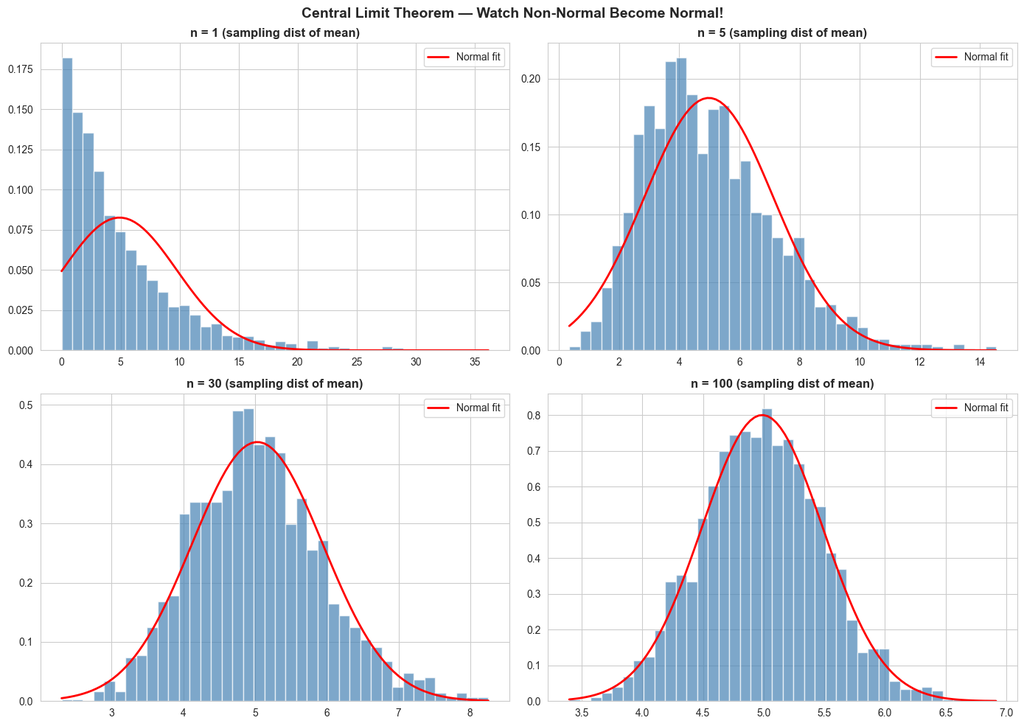

```
CLT: As sample size n → ∞, the distribution of sample means → Normal
Key: n ≥ 30 is the practical threshold for normality
```

```python
# ──────────────────────────────────────────────
# Central Limit Theorem — Visual Demonstration
# ──────────────────────────────────────────────
import numpy as np
import matplotlib.pyplot as plt
from scipy import stats

np.random.seed(42)

# Population: Exponential distribution (clearly non-normal)
population = np.random.exponential(scale=5, size=100000)

fig, axes = plt.subplots(2, 2, figsize=(14, 10))
fig.suptitle('Central Limit Theorem — Watch Non-Normal Become Normal!', fontsize=14, fontweight='bold')

sample_sizes = [1, 5, 30, 100]
for ax, n in zip(axes.flat, sample_sizes):
    means = [np.random.choice(population, n).mean() for _ in range(2000)]
    ax.hist(means, bins=40, density=True, alpha=0.7, color='steelblue', edgecolor='white')

    # Overlay normal curve
    x = np.linspace(min(means), max(means), 100)
    ax.plot(x, stats.norm.pdf(x, np.mean(means), np.std(means)),
            'r-', linewidth=2, label='Normal fit')

    ax.set_title(f'n = {n} (sampling dist of mean)', fontweight='bold')
    ax.legend()

plt.tight_layout()
plt.show()
print('CLT: As sample size n → ∞, the distribution of sample means → Normal')
print('Key: n ≥ 30 is the practical threshold for normality')
```

#### Standard Error

The standard error measures **how much the sample statistic varies** across different samples:

$$SE_{\bar{x}} = \frac{s}{\sqrt{n}}$$

| Statistic | Standard Error |
| --- | --- |
| Sample mean | $SE = s / \sqrt{n}$ |
| Sample proportion | $SE = \sqrt{\hat{p}(1-\hat{p})/n}$ |
| Difference in means | $SE = \sqrt{s_1^2/n_1 + s_2^2/n_2}$ |
| Difference in proportions | $SE = \sqrt{\hat{p}_1(1-\hat{p}_1)/n_1 + \hat{p}_2(1-\hat{p}_2)/n_2}$ |

> **Key insight:** to halve the standard error, you need to **quadruple** the sample size ($SE \propto 1/\sqrt{n}$).

#### Point Estimation

| Property | Meaning |
| --- | --- |
| **Unbiased** | $E[\hat{\theta}] = \theta$ — on average equals true value |
| **Consistent** | $\hat{\theta} \to \theta$ as $n \to \infty$ — converges with more data |
| **Efficient** | Smallest variance among unbiased estimators |
| **Sufficient** | Uses all information in the sample |

| Parameter | Point Estimator |
| --- | --- |
| Population mean (μ) | Sample mean ($\bar{x}$) |
| Population variance (σ²) | Sample variance ($s^2$, with $n-1$) |
| Population proportion (π) | Sample proportion ($\hat{p}$) |

#### Confidence Intervals

A confidence interval gives a **range of plausible values** for a population parameter.

$$\text{CI} = \text{point estimate} \pm z^* \times SE$$

| Parameter | CI Formula | When to Use |
| --- | --- | --- |
| Mean (σ known) | $\bar{x} \pm z^* \cdot \frac{\sigma}{\sqrt{n}}$ | Large n, known σ (rare) |
| Mean (σ unknown) | $\bar{x} \pm t^* \cdot \frac{s}{\sqrt{n}}$ | Small n or unknown σ (most common) |
| Proportion | $\hat{p} \pm z^* \cdot \sqrt{\frac{\hat{p}(1-\hat{p})}{n}}$ | Large n (np ≥ 10 and n(1−p) ≥ 10) |

**Critical values ($z^*$) for common confidence levels:**

| Confidence Level | $z^*$ |
| --- | --- |
| 90% | 1.645 |
| 95% | 1.960 |
| 99% | 2.576 |

```python
from scipy import stats
import numpy as np

# 95% CI for mean
data = np.array([72, 68, 75, 80, 65, 73, 78, 71, 69, 77])
n = len(data)
mean = np.mean(data)
se = stats.sem(data)  # standard error of mean
t_crit = stats.t.ppf(0.975, df=n-1)  # two-tailed

ci_lower = mean - t_crit * se
ci_upper = mean + t_crit * se
print(f'95% CI: ({ci_lower:.2f}, {ci_upper:.2f})')

# Using scipy directly
ci = stats.t.interval(0.95, df=n-1, loc=mean, scale=se)
print(f'95% CI (scipy): ({ci[0]:.2f}, {ci[1]:.2f})')

# Sample size needed for margin of error E with known sigma
z_star = 1.96  # 95%
sigma = 15     # estimated SD
E = 3          # desired margin of error
n_needed = (z_star * sigma / E) ** 2
print(f'Sample size needed: {int(np.ceil(n_needed))}')
```

```
95% CI: (69.40, 76.20)
95% CI (scipy): (69.40, 76.20)
Sample size needed: 97
```

#### Interpreting Confidence Intervals Correctly

| ✅ Correct | ❌ Incorrect |
| --- | --- |
| If we repeated this study many times, 95% of the CIs would contain μ | There is a 95% probability that μ is in this interval |
| We are 95% confident this procedure captures μ | μ has a 95% chance of being between a and b |

> The parameter μ is **fixed** — it's either in the interval or not. The confidence level refers to the **procedure**, not the specific interval.

#### Sampling & Estimation — Interview Questions

| # | Question | Answer |
| --- | --- | --- |
| 1 | Explain the Central Limit Theorem. Why is it important? | • Sample means converge to Normal distribution as n increases • Regardless of population shape (uniform, exponential, skewed) • Enables: z-tests, t-tests, confidence intervals for any population • Pra… |
| 2 | What is the difference between standard deviation and standard error? | • SD: spread of individual observations in a dataset ($s$) • SE: spread of the sampling distribution of a statistic ($s/\sqrt{n}$) • SD doesn't decrease with more data; SE does • SE measures precision… |
| 3 | Explain stratified sampling. When would you use it? | • Divide population into homogeneous subgroups (strata), then sample from each • Use when: subgroups have different characteristics (age groups, regions) • Reduces sampling variability vs SRS • Guaran… |
| 4 | What is a confidence interval? Interpret a 95% CI of (45, 55). | • Range expected to contain population parameter with stated confidence • 95% CI of (45, 55): if we repeated the study 100 times, ~95 of those CIs would contain the true mean • It does NOT mean 95% pr… |
| 5 | How does sample size affect confidence interval width? | • Width = $2 \times z^* \times SE = 2z^* \cdot s/\sqrt{n}$ • Larger n → smaller SE → narrower CI → more precise • Diminishing returns: doubling n reduces width by ~30% (factor of $\sqrt{2}$) • To halv… |
| 6 | What is selection bias? Give an example. | • Sample is not representative of population due to selection process • Example: phone survey excludes people without phones • Example: Amazon reviews are self-selected (strong opinions) • Fix: random… |
| 7 | What is the bootstrap? When would you use it? | • Resample from your data with replacement many times (e.g., 10,000) • Compute statistic on each resample → bootstrap distribution • Use: when no parametric formula for SE or CI exists • Gives CI for … |
| 8 | What does 'unbiased estimator' mean? | • $E[\hat{\theta}] = \theta$ — on average equals the true parameter • Sample mean is unbiased for population mean • Sample variance with $n-1$ is unbiased for population variance • Unbiased ≠ accurate… |
| 9 | What is the margin of error? | • Half-width of the confidence interval: $E = z^* \times SE$ • Represents maximum expected difference between estimate and truth • Depends on: confidence level, variability, sample size • Reported in … |
| 10 | Explain the difference between precision and accuracy in estimation. | • Accuracy (bias): is the estimator centered on the true value? • Precision (variance): how tightly clustered are the estimates? • Ideal: high accuracy + high precision (low bias + low variance) • MSE… |
| 11 | When would you use cluster sampling instead of stratified? | • Cluster: when it's impractical to list entire population but easy to identify clusters • Example: sample schools (clusters) then test all students within selected schools • Cheaper than individual S… |
| 12 | What is non-response bias? How do you mitigate it? | • When responders differ systematically from non-responders • Example: healthy people more likely to respond to health survey • Mitigation: follow-up reminders, incentives, imputation for missing • An… |
| 13 | What happens to the sampling distribution as n increases? | • Shape: becomes more normal (CLT) • Center: stays at μ (unbiased) • Spread: SE = σ/√n decreases • Net effect: more precise, more reliable estimates |
| 14 | How do you determine sample size for a study? | • Specify: desired confidence level (95%), margin of error (E), estimated SD • $n = (z^* \cdot \sigma / E)^2$ for means • $n = z^{*2} \cdot p(1-p) / E^2$ for proportions (use p=0.5 if unknown) • Rule:… |
| 15 | What is the finite population correction factor? | • $FPC = \sqrt{\frac{N-n}{N-1}}$ — reduces SE when sampling large fraction • Multiply SE by FPC when $n/N > 5\%$ • If sampling 50% of population, SE is reduced by ~29% • Intuition: sampling the entire… |
| 16 | Explain MLE (Maximum Likelihood Estimation). | • Find parameter values that maximize the probability of observing the data • $\hat{\theta}_{MLE} = \arg\max_{\theta} \prod_{i=1}^n f(x_i \mid \theta)$ • In practice: maximize log-likelihood (easier t… |
| 17 | What is the bootstrap confidence interval? Step by step. | • 1. From original sample of n, resample n observations WITH replacement • 2. Compute statistic (mean, median, etc.) on resample • 3. Repeat B times (B = 1000-10000) • 4. CI = percentile method: 2.5th… |
| 18 | What is the jackknife resampling method? | • Leave-one-out: compute statistic on n-1 observations, n times • Estimate bias and SE of estimator • Less computationally intensive than bootstrap • More suitable for smooth statistics (mean, varianc… |
| 19 | Explain the bias-variance tradeoff in estimation. | • Biased estimator may have lower MSE than unbiased one • $MSE = \text{Bias}^2 + \text{Variance}$ • Example: shrinkage estimators (ridge regression) are biased but lower variance • James-Stein estimat… |
| 20 | What is a consistent estimator? | • $\hat{\theta}_n \xrightarrow{P} \theta$ as $n \to \infty$ • With enough data, the estimate converges to the true value • Sample mean and sample variance are consistent • Consistency doesn't require … |
| 21 | You want 95% CI for customer satisfaction with ±2% margin. How large a sample? | • Proportion CI: $n = z^{*2} \cdot p(1-p) / E^2$ • Conservative (p=0.5): $n = (1.96)^2 \times 0.25 / (0.02)^2 = 2401$ • If expect p ≈ 0.8: $n = (1.96)^2 \times 0.16 / (0.02)^2 = 1537$ • Always round u… |
| 22 | What is the method of moments? How does it differ from MLE? | • Set population moments equal to sample moments, solve for parameters • Simpler than MLE but generally less efficient • MLE: maximizes likelihood function (uses full data distribution) • MoM: matches… |
| 23 | Explain the concept of power in relation to sample size. | • Power = P(reject H₀ &#124; H₀ is false) = 1 − β • Larger n → more power (detect smaller effects) • Power analysis: determine n needed to detect given effect size • Standard target: 80% power (β = 0.… |
| 24 | What is the plug-in principle? | • Estimate population quantities by substituting sample quantities • Replace F (pop CDF) with $\hat{F}_n$ (empirical CDF) • Example: estimate $\sigma^2$ by $s^2$, $\mu$ by $\bar{x}$ • Foundation of bo… |
| 25 | How does the CLT apply to proportions? | • Sample proportion $\hat{p}$ is a mean of 0/1 observations • CLT: $\hat{p} \sim N(p, p(1-p)/n)$ for large n • Rule of thumb: np ≥ 10 and n(1−p) ≥ 10 • Enables: proportion z-tests and CIs |

### Part 6: Statistical Inference

Statistical inference uses sample data to draw conclusions about populations. The two main tools: **confidence intervals** (estimate parameters) and **hypothesis tests** (make decisions).

#### Hypothesis Testing Framework

[output not shown]

#### Null vs Alternative Hypothesis

|  | Null Hypothesis ($H_0$) | Alternative Hypothesis ($H_1$ or $H_a$) |
| --- | --- | --- |
| **Claim** | No effect, no difference, status quo | Effect exists, difference present |
| **Contains** | Equality (=, ≤, ≥) | Inequality (≠, >, <) |
| **Burden** | Assumed true until evidence says otherwise | Must be supported by data |
| **Decision** | Reject or fail to reject (never 'accept') | Accept or do not accept |

#### Type I and Type II Errors

|  | $H_0$ is actually TRUE | $H_0$ is actually FALSE |
| --- | --- | --- |
| **Reject $H_0$** | ❌ Type I Error ($\alpha$) — False Positive | ✅ Correct (Power = $1-\beta$) |
| **Fail to reject $H_0$** | ✅ Correct | ❌ Type II Error ($\beta$) — False Negative |

| Error | Probability | Analogy | Consequence |
| --- | --- | --- | --- |
| **Type I (α)** | Significance level (usually 0.05) | False alarm / crying wolf | Unnecessary action, wasted resources |
| **Type II (β)** | Related to power (1−β) | Missed detection | Failed to detect real effect |

> **Trade-off:** Reducing α (stricter threshold) increases β (harder to detect real effects). Balance with sample size and effect size.

#### p-value

The p-value is the probability of observing data **as or more extreme** than what was observed, **assuming $H_0$ is true**.

| p-value | Interpretation |
| --- | --- |
| p < 0.001 | Very strong evidence against $H_0$ |
| p < 0.01 | Strong evidence |
| p < 0.05 | Moderate evidence (conventional threshold) |
| p < 0.10 | Weak evidence |
| p ≥ 0.10 | Little to no evidence against $H_0$ |

**Common misinterpretations (all WRONG):**

- ❌ p-value = probability $H_0$ is true
- ❌ p-value = probability the result is due to chance
- ❌ 1 − p = probability of replication
- ❌ Small p = large effect size

#### One-tailed vs Two-tailed Tests

|  | One-tailed | Two-tailed |
| --- | --- | --- |
| **$H_1$** | $\mu > \mu_0$ or $\mu < \mu_0$ | $\mu \neq \mu_0$ |
| **Rejection region** | One tail only | Both tails |
| **Power** | Higher for detecting one direction | Lower (split across two tails) |
| **When to use** | Strong prior for direction | No prior expectation of direction |

> **Rule:** Use two-tailed unless you have a **strong, pre-specified reason** to expect a specific direction.

#### Statistical Power

**Power** = $P(\text{reject } H_0 \mid H_0 \text{ false})$ = $1 - \beta$

| Factor | Effect on Power |
| --- | --- |
| ↑ Sample size (n) | ↑ Power |
| ↑ Effect size (Δ) | ↑ Power |
| ↑ Significance level (α) | ↑ Power (but more Type I errors) |
| ↓ Variability (σ) | ↑ Power |

```python
from statsmodels.stats.power import TTestIndPower

# Power analysis: how many subjects per group?
analysis = TTestIndPower()
n = analysis.solve_power(effect_size=0.5, alpha=0.05, power=0.80)
print(f'Sample size per group: {int(np.ceil(n))}')  # ~64 per group

# What power do we have with n=50 per group?
power = analysis.solve_power(effect_size=0.5, alpha=0.05, nobs1=50)
print(f'Power with n=50: {power:.3f}')  # ~0.70
```

```
Sample size per group: 64
Power with n=50: 0.697
```

#### Effect Size

P-values alone don't tell you **how big** the effect is. Effect size does.

| Measure | Formula | Small | Medium | Large |
| --- | --- | --- | --- | --- |
| **Cohen's d** (means) | $d = \frac{\bar{x}_1 - \bar{x}_2}{s_{pooled}}$ | 0.2 | 0.5 | 0.8 |
| **Cohen's h** (proportions) | $h = 2\arcsin\sqrt{p_1} - 2\arcsin\sqrt{p_2}$ | 0.2 | 0.5 | 0.8 |
| **η²** (ANOVA) | $\frac{SS_{between}}{SS_{total}}$ | 0.01 | 0.06 | 0.14 |
| **r** (correlation) | Pearson's r | 0.1 | 0.3 | 0.5 |

> With large n, you can detect trivially small effects. Always report effect size alongside p-value.

#### Multiple Testing Problem

Running many tests inflates false positive rate. If you run 20 tests at α=0.05, you expect ~1 false positive:

$$P(\text{at least 1 false positive}) = 1 - (1 - \alpha)^m \approx 1 - 0.95^{20} \approx 0.64$$

| Correction Method | How It Works | Strictness |
| --- | --- | --- |
| **Bonferroni** | Divide α by number of tests: $\alpha_{adj} = \alpha/m$ | Very conservative |
| **Holm-Bonferroni** | Step-down: order p-values, compare to decreasing thresholds | Less conservative than Bonferroni |
| **Benjamini-Hochberg (FDR)** | Controls False Discovery Rate instead of FWER | Most powerful, allows some false positives |

#### Statistical Inference — Interview Questions

| # | Question | Answer |
| --- | --- | --- |
| 1 | What is a p-value? Explain to a non-technical person. | • If there truly is no effect, the p-value is the chance of seeing results this dramatic or more • Like a surprise meter: lower p-value = more surprising result • p = 0.03 means only 3% chance of this… |
| 2 | Type I vs Type II error — which is worse? | • Depends on context; Type I = false positive, Type II = false negative • Medical screening: Type II worse (miss cancer diagnosis) • Criminal trial: Type I worse (convict innocent person) • Spam filte… |
| 3 | What is statistical power and why does it matter? | • Power = P(detect real effect) = 1 − β • Low power → waste resources on study that can't detect effects • Typical goal: 80% power • Increase by: larger n, larger effect, higher α, lower σ |
| 4 | Explain the difference between statistical significance and practical significance. | • Statistical: p < α (effect unlikely due to chance alone) • Practical: effect is large enough to matter in real-world • Large n can make trivial differences significant (p < 0.001 for $0.01 differenc… |
| 5 | What is the multiple testing problem? How do you solve it? | • Running many tests inflates false positive rate • 20 tests at α=0.05 → 64% chance of at least 1 false positive • Bonferroni: α/m (conservative); BH-FDR: control fraction of false discoveries • Pre-r… |
| 6 | What is p-hacking? | • Manipulating analysis to get p < 0.05: trying many variables, subgroups, transformations until 'significant' • Cherry-picking: only reporting significant results • Garden of forking paths: many anal… |
| 7 | Explain effect size. Why can't you rely on p-value alone? | • Effect size quantifies the magnitude of difference/relationship • p-value depends on n: huge n → tiny effect still significant • Cohen's d=0.1 with p=0.001 (n=10000) is statistically significant but… |
| 8 | What is the significance level α? How do you choose it? | • Maximum acceptable Type I error rate (false positive rate) • Convention: 0.05, but not universal or optimal • High-stakes (genomics, drug trials): use α = 0.01 or 0.001 • Exploratory analysis: α = 0… |
| 9 | What does 'fail to reject H₀' mean? Is it the same as accepting H₀? | • NO — 'fail to reject' ≠ 'accept' • Absence of evidence ≠ evidence of absence • Possible reasons: true H₀, or insufficient power to detect H₁ • Correct phrasing: 'insufficient evidence to conclude an… |
| 10 | When would you use a one-tailed test? | • When you have a strong, pre-specified directional hypothesis • Example: new drug should INCREASE lifespan (not decrease) • More powerful for detecting effect in the expected direction • Warning: if … |
| 11 | What is a confidence interval and how does it relate to hypothesis testing? | • 95% CI contains all parameter values that would NOT be rejected at α = 0.05 • If 95% CI for $\mu_1 - \mu_2$ doesn't include 0 → reject $H_0: \mu_1 = \mu_2$ • CI gives more information: direction, ma… |
| 12 | What is the Bonferroni correction? When is it too conservative? | • $\alpha_{adj} = \alpha / m$ where m = number of tests • 100 tests at α=0.05 → need p < 0.0005 per test • Too conservative when tests are correlated (overlapping hypotheses) • Alternative: BH-FDR is … |
| 13 | Explain FDR (False Discovery Rate) vs FWER (Family-Wise Error Rate). | • FWER: P(at least 1 false positive) — Bonferroni controls this • FDR: expected proportion of false positives among all rejections • FDR is less strict → more discoveries (more power) • FDR preferred … |
| 14 | What is the power analysis? Walk through the process. | • 1. Set desired power (80%), significance level (α=0.05) • 2. Estimate expected effect size (Cohen's d from pilot/literature) • 3. Estimate variability (σ from pilot data) • 4. Compute required n usi… |
| 15 | Why is n=30 often cited as 'large enough'? | • CLT: sampling distribution of mean is approximately normal for n ≥ 30 • Rule of thumb, not a hard rule — depends on population shape • Highly skewed: need n > 100; symmetric: n = 15 may suffice • Be… |
| 16 | What assumptions do parametric tests make? | • Normality: data (or residuals) approximately normal • Homogeneity of variance: equal variances across groups • Independence: observations are independent • If violated: use non-parametric alternativ… |
| 17 | What is a one-sample t-test? When do you use it? | • Test if sample mean differs from known/hypothesized value • $t = (\bar{x} - \mu_0) / (s/\sqrt{n})$, df = n-1 • Example: is average delivery time different from 30 minutes? • Assumes: independent obs… |
| 18 | What is Bayesian hypothesis testing? How does it differ? | • Instead of p-value, compute Bayes Factor: evidence for H₁ vs H₀ • Incorporates prior beliefs into analysis • Result: posterior probability of each hypothesis • No arbitrary α cutoff; continuous meas… |
| 19 | What is the reproducibility crisis? | • Many published findings fail to replicate (psychology, medicine, etc.) • Causes: p-hacking, publication bias, small samples, HARKing • Solutions: pre-registration, larger samples, report effect size… |
| 20 | How do you handle non-normal data in hypothesis testing? | • Transform: log, sqrt, Box-Cox to make data more normal • Non-parametric tests: Mann-Whitney, Wilcoxon, Kruskal-Wallis • Bootstrap: resample to build distribution of test statistic • Permutation test… |
| 21 | Explain the Neyman-Pearson framework vs Fisher approach. | • Fisher: p-value as measure of evidence; no pre-set α; continuous evidence • Neyman-Pearson: fixed α, decision-making framework, control error rates • Modern practice: hybrid — use α=0.05 (NP) but re… |
| 22 | What is equivalence testing? | • Test whether effect is WITHIN a practical range (not just different from 0) • Two one-sided tests (TOST): show effect is both > −Δ and < +Δ • Use when: you want to show treatments are equivalent (bi… |
| 23 | What is P(outcome) vs P(test result)? | • P(outcome): probability of specific data given model • P(test result): probability of the statistical test outcome • p-value is P(data &#124; H₀), NOT P(H₀ &#124; data) • To get P(H₀ &#124; data), n… |
| 24 | When should you use a non-parametric test? | • Data is ordinal (ratings, ranks) • Small sample size with non-normal distribution • Outliers present that would distort parametric tests • Don't want to assume any specific distribution |
| 25 | What is a permutation test? | • Shuffle group labels, recompute test statistic many times • p-value = proportion of permutations as extreme as observed • No distributional assumptions — exact test • Works for any test statistic; c… |

### Part 7: Hypothesis Tests

This section covers the specific tests you'll be asked about in interviews — when to use each, assumptions, and Python implementation.

#### Test Selection Guide

| Scenario | Test | Assumptions |
| --- | --- | --- |
| 1 mean vs known value (σ known) | **Z-test** | Normal pop or large n |
| 1 mean vs known value (σ unknown) | **One-sample t-test** | Normal pop or large n |
| 2 independent means | **Two-sample t-test** | Normal, independent, equal var (or Welch) |
| 2 paired means | **Paired t-test** | Normal differences |
| 3+ independent means | **One-way ANOVA** | Normal, equal var, independent |
| 2+ categorical variables | **Chi-square test of independence** | Expected count ≥ 5 |
| Fit to expected distribution | **Chi-square goodness-of-fit** | Expected count ≥ 5 |
| 2 independent medians | **Mann-Whitney U** | Ordinal or non-normal |
| 2 paired medians | **Wilcoxon signed-rank** | Symmetric differences |
| 3+ independent medians | **Kruskal-Wallis** | Ordinal or non-normal |
| 2 proportions | **Two-proportion Z-test** | Large n |
| Variance comparison | **F-test / Levene's test** | Normal (F-test) |
| Normality check | **Shapiro-Wilk** | n < 5000 |

#### Z-Test

Used when population standard deviation ($\sigma$) is **known** (rare in practice).

$$z = \frac{\bar{x} - \mu_0}{\sigma / \sqrt{n}}$$

```python
from scipy import stats
import numpy as np

# One-sample Z-test: Is mean height different from 170 cm? (sigma=10 known)
data = np.array([172, 168, 175, 180, 165, 173, 177, 169, 171, 174])
mu_0, sigma = 170, 10
z_stat = (np.mean(data) - mu_0) / (sigma / np.sqrt(len(data)))
p_value = 2 * (1 - stats.norm.cdf(abs(z_stat)))  # two-tailed
print(f'Z = {z_stat:.3f}, p = {p_value:.4f}')
```

```
Z = 0.759, p = 0.4479
```

#### T-Tests

| Type | When | Formula |
| --- | --- | --- |
| **One-sample** | Compare sample mean to known value | $t = \frac{\bar{x} - \mu_0}{s / \sqrt{n}}$, df = $n-1$ |
| **Two-sample (independent)** | Compare means of 2 groups | $t = \frac{\bar{x}_1 - \bar{x}_2}{\sqrt{s_p^2(1/n_1 + 1/n_2)}}$ |
| **Welch's t-test** | 2 groups, unequal variances | Like two-sample but with adjusted df |
| **Paired** | Same subjects measured twice | $t = \frac{\bar{d}}{s_d / \sqrt{n}}$, df = $n-1$ |

```python
# One-sample t-test: Is mean delivery time different from 30 minutes?
delivery = [28, 32, 35, 25, 30, 33, 29, 31, 27, 34]
t_stat, p_val = stats.ttest_1samp(delivery, popmean=30)
print(f'One-sample t: t={t_stat:.3f}, p={p_val:.4f}')

# Two-sample t-test: Do two groups have different means?
group_a = [85, 90, 78, 92, 88, 76, 95, 87, 82, 91]
group_b = [72, 78, 80, 68, 75, 82, 70, 74, 77, 73]
t_stat, p_val = stats.ttest_ind(group_a, group_b, equal_var=False)  # Welch's
print(f'Two-sample t (Welch): t={t_stat:.3f}, p={p_val:.4f}')

# Paired t-test: Before vs after treatment
before = [120, 135, 128, 140, 132, 125, 138, 130, 142, 136]
after  = [115, 128, 122, 133, 127, 120, 130, 125, 135, 129]
t_stat, p_val = stats.ttest_rel(before, after)
print(f'Paired t: t={t_stat:.3f}, p={p_val:.4f}')

# Effect size: Cohen's d
d = (np.mean(group_a) - np.mean(group_b)) / np.sqrt(
    ((len(group_a)-1)*np.var(group_a,ddof=1) + (len(group_b)-1)*np.var(group_b,ddof=1))
    / (len(group_a)+len(group_b)-2)
)
print(f"Cohen's d = {d:.3f}")  # >0.8 = large effect
```

```
One-sample t: t=0.395, p=0.7022
Two-sample t (Welch): t=4.797, p=0.0002
Paired t: t=17.270, p=0.0000
Cohen's d = 2.145
```

#### ANOVA (Analysis of Variance)

Compares means of **3 or more groups**. Tests whether at least one group mean differs.

$$F = \frac{MS_{between}}{MS_{within}} = \frac{SS_{between} / (k-1)}{SS_{within} / (N-k)}$$

| Component | Measures |
| --- | --- |
| $SS_{between}$ | Variation between group means |
| $SS_{within}$ | Variation within groups (error) |
| Large F | Groups differ more than expected by chance |

**Assumptions:** normality, equal variances (Levene's test), independence.

```python
# One-way ANOVA: 3 teaching methods, compare test scores
method_a = [85, 90, 88, 92, 87]
method_b = [78, 82, 80, 76, 81]
method_c = [92, 95, 89, 94, 91]

f_stat, p_val = stats.f_oneway(method_a, method_b, method_c)
print(f'ANOVA: F={f_stat:.3f}, p={p_val:.4f}')

# If significant → post-hoc pairwise comparisons
from statsmodels.stats.multicomp import pairwise_tukeyhsd
import pandas as pd

all_scores = method_a + method_b + method_c
groups = ['A']*5 + ['B']*5 + ['C']*5
tukey = pairwise_tukeyhsd(all_scores, groups, alpha=0.05)
print(tukey)

# Check equal variance assumption
levene_stat, levene_p = stats.levene(method_a, method_b, method_c)
print(f'Levene\'s test: stat={levene_stat:.3f}, p={levene_p:.4f}')
```

```
ANOVA: F=34.479, p=0.0000
 Multiple Comparison of Means - Tukey HSD, FWER=0.05
=====================================================
group1 group2 meandiff p-adj   lower    upper  reject
-----------------------------------------------------
     A      B     -9.0 0.0003 -13.2239 -4.7761   True
     A      C      3.8 0.0796  -0.4239  8.0239  False
     B      C     12.8    0.0   8.5761 17.0239   True
-----------------------------------------------------
Levene's test: stat=0.031, p=0.9693
```

**ANOVA Extensions:**

| Type | Use Case |
| --- | --- |
| **One-way** | 1 factor, 3+ levels |
| **Two-way** | 2 factors + interaction effect |
| **Repeated Measures** | Same subjects across conditions (paired ANOVA) |
| **MANOVA** | Multiple dependent variables |
| **ANCOVA** | ANOVA + covariate adjustment |

#### Chi-Square Tests

| Test | Purpose | Formula |
| --- | --- | --- |
| **Goodness of fit** | Does data match expected distribution? | $\chi^2 = \sum \frac{(O_i - E_i)^2}{E_i}$ |
| **Independence** | Are two categorical variables related? | Same formula, 2D contingency table |

```python
# Chi-square test of independence: Is purchase related to gender?
#                Male  Female
# Purchased       40     60
# Not purchased   60     40

observed = np.array([[40, 60], [60, 40]])
chi2, p_val, dof, expected = stats.chi2_contingency(observed)
print(f'Chi-square: χ²={chi2:.3f}, p={p_val:.4f}, df={dof}')
print(f'Expected:\n{expected}')

# Effect size: Cramér's V
n = observed.sum()
k = min(observed.shape)
cramers_v = np.sqrt(chi2 / (n * (k - 1)))
print(f"Cramér's V = {cramers_v:.3f}")

# Chi-square goodness of fit: Is a die fair?
observed_rolls = [18, 22, 16, 20, 24, 20]  # 120 rolls
expected_rolls = [20, 20, 20, 20, 20, 20]
chi2, p_val = stats.chisquare(observed_rolls, expected_rolls)
print(f'Goodness of fit: χ²={chi2:.3f}, p={p_val:.4f}')
```

```
Chi-square: χ²=7.220, p=0.0072, df=1
Expected:
[[50. 50.]
 [50. 50.]]
Cramér's V = 0.190
Goodness of fit: χ²=2.000, p=0.8491
```

#### Non-Parametric Tests

Used when assumptions of parametric tests (normality, equal variance) are violated.

| Parametric Test | Non-Parametric Alternative | Data Type |
| --- | --- | --- |
| One-sample t-test | Wilcoxon signed-rank | Ordinal / non-normal |
| Two-sample t-test | Mann-Whitney U | Ordinal / non-normal |
| Paired t-test | Wilcoxon signed-rank | Paired ordinal |
| One-way ANOVA | Kruskal-Wallis | 3+ groups, non-normal |
| Repeated measures ANOVA | Friedman test | Repeated measures, non-normal |
| Pearson correlation | Spearman correlation | Non-linear or ordinal |

```python
# Mann-Whitney U: compare two groups (non-parametric)
group_x = [2, 4, 6, 8, 10, 12, 14, 18, 25, 50]
group_y = [1, 3, 5, 7, 9, 11, 13, 15, 17, 19]
u_stat, p_val = stats.mannwhitneyu(group_x, group_y, alternative='two-sided')
print(f'Mann-Whitney U: U={u_stat:.1f}, p={p_val:.4f}')

# Kruskal-Wallis: 3+ groups (non-parametric ANOVA)
g1 = [5, 8, 12, 7, 10]
g2 = [15, 18, 20, 14, 17]
g3 = [25, 30, 22, 28, 27]
h_stat, p_val = stats.kruskal(g1, g2, g3)
print(f'Kruskal-Wallis: H={h_stat:.3f}, p={p_val:.4f}')
```

```
Mann-Whitney U: U=57.0, p=0.6232
Kruskal-Wallis: H=12.500, p=0.0019
```

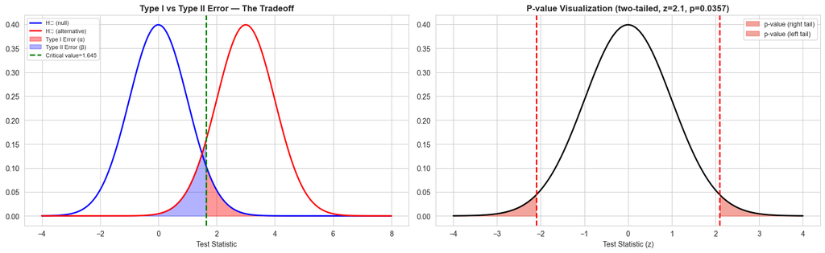

```
If p-value (0.0357) < α (0.05): REJECT H₀
```

```python
# ──────────────────────────────────────────────
# Hypothesis Testing — Visual Guide
# ──────────────────────────────────────────────
import numpy as np
import matplotlib.pyplot as plt
from scipy import stats

fig, axes = plt.subplots(1, 2, figsize=(16, 5))

# 1. Type I vs Type II Error visualization
ax = axes[0]
x = np.linspace(-4, 8, 500)
null = stats.norm.pdf(x, 0, 1)   # H0 distribution
alt = stats.norm.pdf(x, 3, 1)    # H1 distribution
crit = 1.645  # alpha=0.05 one-tailed

ax.plot(x, null, 'b-', linewidth=2, label='H₀ (null)')
ax.plot(x, alt, 'r-', linewidth=2, label='H₁ (alternative)')
ax.fill_between(x, null, where=(x >= crit), alpha=0.4, color='red', label='Type I Error (α)')
ax.fill_between(x, alt, where=(x <= crit), alpha=0.3, color='blue', label='Type II Error (β)')
ax.axvline(crit, color='green', linestyle='--', linewidth=2, label=f'Critical value={crit}')
ax.set_title('Type I vs Type II Error — The Tradeoff', fontweight='bold')
ax.legend(fontsize=8, loc='upper left')
ax.set_xlabel('Test Statistic')

# 2. P-value visualization
ax = axes[1]
x = np.linspace(-4, 4, 500)
y = stats.norm.pdf(x)
test_stat = 2.1
ax.plot(x, y, 'k-', linewidth=2)
ax.fill_between(x, y, where=(x >= test_stat), alpha=0.5, color='#e74c3c', label=f'p-value (right tail)')
ax.fill_between(x, y, where=(x <= -test_stat), alpha=0.5, color='#e74c3c', label=f'p-value (left tail)')
ax.axvline(test_stat, color='red', linestyle='--', linewidth=2)
ax.axvline(-test_stat, color='red', linestyle='--', linewidth=2)
p_val = 2 * (1 - stats.norm.cdf(test_stat))
ax.set_title(f'P-value Visualization (two-tailed, z={test_stat}, p={p_val:.4f})', fontweight='bold')
ax.legend(fontsize=9)
ax.set_xlabel('Test Statistic (z)')

plt.tight_layout()
plt.show()
print(f'If p-value ({p_val:.4f}) < α (0.05): REJECT H₀')
```

#### Hypothesis Tests — Interview Questions

| # | Question | Answer |
| --- | --- | --- |
| 1 | When do you use a t-test vs z-test? | • Z-test: population σ known (very rare in practice) • t-test: population σ unknown, estimated by sample s • t-test with large n → same result as z-test (t → z) • Default: always use t-test unless σ i… |
| 2 | What is the difference between paired and independent t-tests? | • Independent: two separate groups (treatment vs control) • Paired: same subjects measured twice (before vs after) • Paired is more powerful: controls for individual differences • Use paired when: pre… |
| 3 | Explain ANOVA. Why not just do multiple t-tests? | • ANOVA: one test for all groups (controls Type I error) • Multiple t-tests: 3 groups → 3 comparisons → inflated α • 10 groups → 45 pairwise t-tests → ~90% chance of false positive • ANOVA first; if s… |
| 4 | What is Tukey's HSD? | • Post-hoc test after significant ANOVA • Compares all pairwise means while controlling family-wise error rate • Reports: mean difference, CI, adjusted p-value for each pair • Alternatives: Bonferroni… |
| 5 | When do you use chi-square test? | • Both variables are categorical (nominal or ordinal) • Independence: is gender related to product preference? • Goodness-of-fit: does this die produce uniform results? • Assumption: all expected cell… |
| 6 | What is Fisher's exact test? | • Alternative to chi-square for small samples (expected counts < 5) • Computes exact p-value (no approximation) • Computationally expensive for large tables • Standard for 2×2 tables with small n |
| 7 | How do you check ANOVA assumptions? | • Normality: Shapiro-Wilk per group, or check residuals • Equal variance: Levene's test (p > 0.05 → variances equal) • Independence: study design (random assignment) • If violated: use Welch's ANOVA o… |
| 8 | When do you use non-parametric tests? | • Data is ordinal (satisfaction ratings, rankings) • Small sample with non-normal distribution • Outliers present that distort parametric tests • More robust but less powerful than parametric when ass… |
| 9 | What is the Mann-Whitney U test? | • Non-parametric alternative to independent two-sample t-test • Compares distributions via ranks (not means) • H₀: two groups have same distribution • Works for: ordinal data, skewed data, small n |
| 10 | Explain Levene's test. | • Tests equality of variances across groups • H₀: all groups have equal variance • More robust than Bartlett's test (doesn't require normality) • If p < 0.05: use Welch's t-test or Welch's ANOVA |
| 11 | What is a two-way ANOVA? | • Tests effect of 2 factors AND their interaction on a continuous outcome • Main effect A, main effect B, interaction A×B • Example: drug type × dosage on blood pressure • Interaction: effect of one f… |
| 12 | What is ANCOVA? | • ANOVA + a continuous covariate (control variable) • Adjusts group means for the covariate • Example: compare test scores by teaching method, controlling for pre-test score • Increases power by reduc… |
| 13 | What is the Wilcoxon signed-rank test? | • Non-parametric paired test (alternative to paired t-test) • Tests if median difference is zero • Uses ranks of absolute differences • More robust to outliers and non-normality than paired t |
| 14 | How do you interpret the F-statistic in ANOVA? | • F = between-group variance / within-group variance • F ≈ 1: groups are similar (variation explained by chance) • F >> 1: groups differ significantly (real effect) • Report: F(df_between, df_within) … |
| 15 | What post-hoc tests are available after ANOVA? | • Tukey's HSD: all pairwise comparisons, controls FWER • Bonferroni: simpler, more conservative • Dunnett's: compare all groups to one control • Games-Howell: when variances are unequal |
| 16 | How do you test for normality? | • Shapiro-Wilk: most powerful for n < 5000 (preferred) • Kolmogorov-Smirnov: compare to any distribution • Anderson-Darling: more sensitive to tails • Visual: Q-Q plot (points on line = normal), histo… |
| 17 | What is a two-proportion z-test? | • Compares two sample proportions (e.g., conversion rates) • $z = (\hat{p}_1 - \hat{p}_2) / SE$ • Example: A/B test — is version A conversion higher than B? • Assumption: $n\hat{p} \geq 10$ and $n(1-\… |
| 18 | What is the Kolmogorov-Smirnov test? | • Compares sample CDF to theoretical CDF (or two sample CDFs) • D-statistic: maximum distance between CDFs • Non-parametric, distribution-free • Less powerful than Shapiro-Wilk for normality testing |
| 19 | How do you choose between parametric and non-parametric? | • Check normality (Shapiro-Wilk, Q-Q plot) • Check equal variance (Levene's test) • Large n (> 30): parametric often robust to non-normality (CLT) • When in doubt: run both — if results agree, report … |
| 20 | What is the Friedman test? | • Non-parametric alternative to repeated measures ANOVA • Ranks data within each subject across conditions • H₀: no difference across conditions • Example: rate 3 products on ordinal scale; same rater… |
| 21 | What is the Kruskal-Wallis test? | • Non-parametric one-way ANOVA (compare 3+ groups) • Based on ranks of all observations combined • $H_0$: all groups have same distribution • If significant → post-hoc: Dunn's test with Bonferroni cor… |
| 22 | What effect size measures exist for chi-square? | • Cramér's V: $\sqrt{\chi^2 / (n \cdot (\min(r,c) - 1))}$, range [0, 1] • Phi (φ): for 2×2 tables specifically • Small: 0.1, Medium: 0.3, Large: 0.5 • Report alongside χ² and p-value |
| 23 | What is McNemar's test? | • Chi-square for paired/matched categorical data • Before/after treatment: did proportion of 'yes' change? • Uses 2×2 table of discordant pairs only • Example: same patients before/after intervention |
| 24 | What is the Shapiro-Wilk test and how do you interpret it? | • H₀: data comes from a normal distribution • $p > 0.05$: fail to reject → data is consistent with normality • $p < 0.05$: reject → data is not normal • Caveat: large n → almost always significant (mi… |
| 25 | A/B test setup: walk through the hypothesis testing process. | • 1. H₀: conversion_A = conversion_B; H₁: conversion_A ≠ conversion_B • 2. Choose α = 0.05, power = 0.80, minimum detectable effect • 3. Power analysis → required sample size per variant • 4. Run expe… |
| 26 | What is a permutation test and when would you prefer it? | • Shuffle labels between groups, recompute statistic many times • p-value = fraction of permutations as extreme as observed • No distributional assumptions — exact under exchangeability • Prefer when:… |
| 27 | How does Welch's t-test differ from Student's t-test? | • Student's: assumes equal variances in both groups • Welch's: does NOT assume equal variances (adjusts df) • Welch's is always safe to use — performs well even with equal variances • Default in most … |
| 28 | What is the likelihood ratio test? | • Compare two nested models: full vs reduced • $\Lambda = -2 \ln(L_{\text{reduced}} / L_{\text{full}})$ • $\Lambda \sim \chi^2(\text{df difference})$ under H₀ • Used in logistic regression, GLMs, stru… |
| 29 | What is a Wald test? | • Tests if a parameter is significantly different from zero • Wald = $(\hat{\theta} / SE(\hat{\theta}))^2 \sim \chi^2(1)$ • Used in: logistic regression (coefficient significance) • Equivalent to z-te… |
| 30 | How would you test if a coin is fair with 100 flips showing 60 heads? | • H₀: p = 0.5; H₁: p ≠ 0.5 • Binomial test: `stats.binom_test(60, 100, 0.5)` → p ≈ 0.057 • Or z-test for proportion: z = (0.60 - 0.50) / √(0.25/100) = 2.0 → p ≈ 0.046 • Marginal — depends on exact tes… |

### Part 8: Correlation & Covariance

Correlation quantifies the **strength and direction** of the relationship between two variables. It's one of the most tested topics in data science interviews.

#### Covariance

Measures how two variables change together:

$$\text{Cov}(X, Y) = \frac{\sum_{i=1}^n (x_i - \bar{x})(y_i - \bar{y})}{n - 1}$$

| Value | Interpretation |
| --- | --- |
| Cov > 0 | Variables tend to increase together |
| Cov < 0 | One increases as the other decreases |
| Cov ≈ 0 | No linear relationship |

**Problem:** Covariance is scale-dependent (depends on units). Solution → **correlation** (standardized covariance).

#### Correlation Coefficients

| Coefficient | Formula | Range | Measures | Assumptions |
| --- | --- | --- | --- | --- |
| **Pearson (r)** | $r = \frac{\text{Cov}(X,Y)}{s_X s_Y}$ | [−1, +1] | Linear relationship | Continuous, normal, no outliers |
| **Spearman (ρ)** | Pearson on ranks | [−1, +1] | Monotonic relationship | Ordinal or non-normal |
| **Kendall (τ)** | Based on concordant/discordant pairs | [−1, +1] | Monotonic, robust | Small n, many ties |
| **Point-biserial** | Pearson where one var is binary | [−1, +1] | Association with binary | One continuous, one binary |

| r Value | Strength |
| --- | --- |
| 0.00 – 0.19 | Very weak |
| 0.20 – 0.39 | Weak |
| 0.40 – 0.59 | Moderate |
| 0.60 – 0.79 | Strong |
| 0.80 – 1.00 | Very strong |

```python
import numpy as np
from scipy import stats

# Generate correlated data
np.random.seed(42)
x = np.random.normal(50, 10, 100)
y = 2 * x + np.random.normal(0, 5, 100)  # strong positive correlation

# Pearson correlation
r_pearson, p_pearson = stats.pearsonr(x, y)
print(f'Pearson:  r = {r_pearson:.3f}, p = {p_pearson:.4f}')

# Spearman correlation (rank-based)
r_spearman, p_spearman = stats.spearmanr(x, y)
print(f'Spearman: ρ = {r_spearman:.3f}, p = {p_spearman:.4f}')

# Kendall correlation
r_kendall, p_kendall = stats.kendalltau(x, y)
print(f'Kendall:  τ = {r_kendall:.3f}, p = {p_kendall:.4f}')

# Correlation matrix
import pandas as pd
df = pd.DataFrame({'x': x, 'y': y, 'z': np.random.normal(0, 1, 100)})
print(df.corr())  # Pearson by default
```

```
Pearson:  r = 0.965, p = 0.0000
Spearman: ρ = 0.964, p = 0.0000
Kendall:  τ = 0.841, p = 0.0000
          x         y         z
x  1.000000  0.965494  0.190840
y  0.965494  1.000000  0.181469
z  0.190840  0.181469  1.000000
```

#### Correlation vs Causation

| Correlation | Causation |
| --- | --- |
| X and Y move together | X **causes** Y to change |
| Can be spurious (ice cream & drowning) | Requires controlled experiment or causal framework |
| Necessary for causation | Not sufficient from correlation alone |

**Ways to establish causation:**

1. **Randomized Controlled Trial (RCT)** — gold standard
2. **Instrumental Variables** — exploit natural experiments
3. **Difference-in-Differences** — policy change before/after
4. **Regression Discontinuity** — exploit cutoff thresholds
5. **Granger Causality** — temporal precedence (not true causation)

#### Multicollinearity

When independent variables are highly correlated with each other in regression.

| Diagnostic | Threshold | Action |
| --- | --- | --- |
| Pairwise correlation | r > 0.80 | Consider removing one variable |
| VIF (Variance Inflation Factor) | VIF > 5 (some say > 10) | Remove or combine variables |
| Condition number | > 30 | Severe multicollinearity |

$$\text{VIF}_j = \frac{1}{1 - R_j^2}$$

where $R_j^2$ is the R-squared from regressing variable $j$ on all other predictors.

```python
from statsmodels.stats.outliers_influence import variance_inflation_factor
import pandas as pd

# Example: detect multicollinearity
df = pd.DataFrame({
    'x1': np.random.normal(0, 1, 100),
    'x2': np.random.normal(0, 1, 100),
})
df['x3'] = df['x1'] * 0.9 + np.random.normal(0, 0.1, 100)  # highly correlated with x1

# Compute VIF for each feature
X = df[['x1', 'x2', 'x3']]
for i, col in enumerate(X.columns):
    vif = variance_inflation_factor(X.values, i)
    print(f'VIF({col}) = {vif:.2f}')  # x1 and x3 will have high VIF
```

```
VIF(x1) = 77.46
VIF(x2) = 1.05
VIF(x3) = 77.08
```

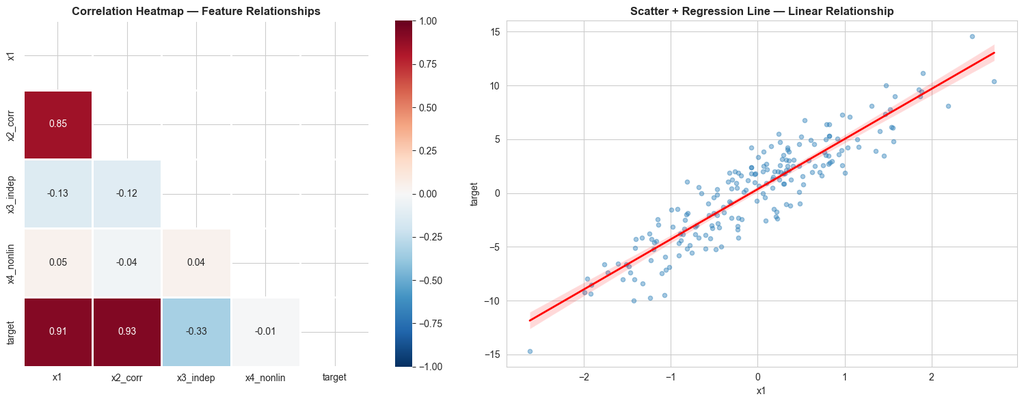

```
Interview tip: Correlation ≠ Causation!
Pearson r(x1, target) = 0.915 — strong linear
Pearson r(x4_nonlin, target) = -0.014 — Pearson misses nonlinear!
```

```python
# ──────────────────────────────────────────────
# Correlation — Heatmap & Scatter Matrix
# ──────────────────────────────────────────────
import numpy as np
import pandas as pd
import matplotlib.pyplot as plt
import seaborn as sns

np.random.seed(42)
n = 200
x1 = np.random.normal(0, 1, n)
x2 = x1 * 0.8 + np.random.normal(0, 0.5, n)    # correlated with x1
x3 = np.random.normal(0, 1, n)                   # independent
x4 = x1 ** 2 + np.random.normal(0, 0.3, n)       # nonlinear relationship
y = 2*x1 + 3*x2 - x3 + np.random.normal(0, 1, n)

df = pd.DataFrame({'x1': x1, 'x2_corr': x2, 'x3_indep': x3, 'x4_nonlin': x4, 'target': y})

fig, axes = plt.subplots(1, 2, figsize=(16, 6))

# Correlation heatmap
corr = df.corr()
mask = np.triu(np.ones_like(corr, dtype=bool))
sns.heatmap(corr, mask=mask, annot=True, fmt='.2f', cmap='RdBu_r',
            center=0, vmin=-1, vmax=1, ax=axes[0],
            square=True, linewidths=1)
axes[0].set_title('Correlation Heatmap — Feature Relationships', fontweight='bold')

# Scatter with regression line
sns.regplot(x='x1', y='target', data=df, ax=axes[1],
            scatter_kws={'alpha': 0.4, 's': 20},
            line_kws={'color': 'red', 'linewidth': 2})
axes[1].set_title('Scatter + Regression Line — Linear Relationship', fontweight='bold')
axes[1].set_xlabel('x1')
axes[1].set_ylabel('target')

plt.tight_layout()
plt.show()

print('Interview tip: Correlation ≠ Causation!')
print(f'Pearson r(x1, target) = {corr.loc["x1","target"]:.3f} — strong linear')
print(f'Pearson r(x4_nonlin, target) = {corr.loc["x4_nonlin","target"]:.3f} — Pearson misses nonlinear!')
```

#### Partial Correlation

The correlation between X and Y **after removing the effect of** a confounding variable Z.

$$r_{XY \cdot Z} = \frac{r_{XY} - r_{XZ} \cdot r_{YZ}}{\sqrt{(1 - r_{XZ}^2)(1 - r_{YZ}^2)}}$$

Used to control for confounders and uncover true relationships.

#### Correlation — Interview Questions

| # | Question | Answer |
| --- | --- | --- |
| 1 | Explain correlation vs causation with an example. | • Ice cream sales and drowning deaths are correlated (r ≈ 0.8) • Cause: both increase in summer (confounding variable: temperature) • Ice cream doesn't cause drowning • Only RCTs or causal inference m… |
| 2 | When would you use Spearman instead of Pearson? | • Non-linear but monotonic relationships (log curves) • Ordinal data (rankings, Likert scales) • Outliers present (Spearman uses ranks, less sensitive) • Non-normal distributions |
| 3 | What is multicollinearity? Why is it a problem? | • Predictors highly correlated with each other • Inflates standard errors of coefficients → unstable estimates • Coefficients change dramatically with small data changes • Doesn't affect predictions, … |
| 4 | How do you detect and handle multicollinearity? | • Detect: correlation matrix (r > 0.8), VIF (> 5 or 10) • Handle: remove one of correlated variables • Combine: PCA to create uncorrelated components • Regularization: Ridge regression shrinks correla… |
| 5 | Can correlation be zero but variables still be related? | • Yes — Pearson measures LINEAR relationship only • $y = x^2$: r = 0 but perfectly dependent • Circular or U-shaped relationships: r ≈ 0 • Solution: use scatter plots, mutual information, or distance … |
| 6 | What is the difference between covariance and correlation? | • Covariance: unstandardized (depends on variable units) • Correlation: standardized covariance (Cov / product of SDs), always in [-1, 1] • Correlation is dimensionless → comparable across variables •… |
| 7 | What is partial correlation? When do you use it? | • Correlation between X and Y controlling for Z • Use when: suspected confounding variable affecting both X and Y • Example: ice cream and drowning correlation vanishes when controlling for temperatur… |
| 8 | You find r = 0.95 between two variables. Your next steps? | • 1. Plot the data — is relationship truly linear? • 2. Check for outliers — one extreme point can inflate r • 3. Check sample size — small n can produce spurious high r • 4. Consider confounders — pa… |
| 9 | What is Kendall's tau? How does it differ from Spearman? | • Both measure monotonic association using ranks • Kendall: based on concordant/discordant pairs — more robust • Spearman: Pearson correlation on ranks — more common • Kendall better for: small sample… |
| 10 | What is distance correlation? | • Measures both linear AND non-linear dependence • dCor = 0 iff X and Y are truly independent (unlike Pearson) • Always ≥ 0; defined for variables of any dimension • Better than Pearson for detecting … |
| 11 | What is autocorrelation? | • Correlation of a time series with lagged versions of itself • $r_k = \text{Corr}(X_t, X_{t-k})$ at lag $k$ • High autocorrelation: violates independence assumption • Tests: Durbin-Watson (lag 1), Lj… |
| 12 | What is the ecological fallacy in correlation? | • Group-level correlations don't apply to individuals • States with higher education correlate with higher income, but individual-level r may be lower • Aggregation can inflate or reverse correlations… |
| 13 | How does sample size affect correlation significance? | • With large n, even trivially small r becomes statistically significant • n=10000: r=0.02 is significant (p < 0.05) but meaningless • Always report r value AND p-value AND confidence interval • Focus… |
| 14 | What is Anscombe's Quartet? | • 4 datasets with identical summary stats (mean, variance, r, regression line) • But completely different scatter plot patterns • Lesson: always visualize data; never rely solely on summary statistics… |
| 15 | If r = 0, are the variables independent? | • NOT necessarily — r = 0 only means no LINEAR relationship • Variables can be perfectly dependent but have r = 0 (e.g., y = x²) • r = 0 + joint normal → independent (special case) • For independence:… |
| 16 | How do you compute correlation for categorical variables? | • Nominal × Nominal: Cramér's V, chi-square • Ordinal × Ordinal: Spearman's ρ, Kendall's τ • Binary × Continuous: point-biserial correlation • Nominal × Continuous: Eta-squared (η²) from ANOVA |
| 17 | What is a correlation matrix and how do you use it? | • Square matrix of pairwise Pearson correlations • Diagonal = 1 (self-correlation); symmetric • Use: identify multicollinearity, feature selection, EDA • Visualize with heatmap (`sns.heatmap(df.corr()… |
| 18 | What is spurious correlation? | • Two variables appear correlated but have no causal connection • Caused by: confounding variable, coincidence, or data mining • Famous: number of Nicolas Cage films ↔ pool drownings • Prevention: dom… |
| 19 | What does r² (coefficient of determination) tell you? | • Proportion of variance in Y explained by X • r = 0.7 → r² = 0.49 → X explains 49% of variance in Y • Remainder (1 − r²) = unexplained variance • r² range [0, 1]; higher = better fit (in simple regre… |
| 20 | How do you test if a correlation is statistically significant? | • H₀: ρ = 0 (population correlation is zero) • $t = r\sqrt{(n-2)/(1-r^2)}$, df = n−2 • scipy: `stats.pearsonr(x, y)` returns (r, p-value) • CI for r via Fisher z-transformation |

### Part 9: Regression

Regression models the relationship between a dependent variable and one or more independent variables. It's the foundation of predictive analytics.

#### Simple Linear Regression

$$\hat{y} = \beta_0 + \beta_1 x$$

| Term | Formula | Interpretation |
| --- | --- | --- |
| $\beta_0$ (intercept) | $\bar{y} - \beta_1 \bar{x}$ | Predicted y when x = 0 |
| $\beta_1$ (slope) | $\frac{\sum(x_i - \bar{x})(y_i - \bar{y})}{\sum(x_i - \bar{x})^2}$ | Change in y per unit change in x |
| $\hat{y}$ | Predicted value | Lies on the regression line |
| $e_i = y_i - \hat{y}_i$ | Residual | Actual − Predicted |

**OLS (Ordinary Least Squares):** Minimizes $\sum_{i=1}^n (y_i - \hat{y}_i)^2$

```python
import numpy as np
from sklearn.linear_model import LinearRegression
import statsmodels.api as sm

# Simple linear regression
X = np.array([1, 2, 3, 4, 5, 6, 7, 8, 9, 10]).reshape(-1, 1)
y = np.array([2.1, 4.0, 5.8, 8.3, 9.7, 12.1, 14.0, 15.5, 18.2, 19.8])

# Using statsmodels (detailed output)
X_sm = sm.add_constant(X)  # add intercept
model = sm.OLS(y, X_sm).fit()
print(model.summary())
# Key outputs: R-squared, coefficients, p-values, confidence intervals

# Using sklearn
reg = LinearRegression().fit(X, y)
print(f'Intercept: {reg.intercept_:.3f}')
print(f'Slope: {reg.coef_[0]:.3f}')
print(f'R²: {reg.score(X, y):.4f}')
```

```
                            OLS Regression Results
==============================================================================
Dep. Variable:                      y   R-squared:                       0.998
Model:                            OLS   Adj. R-squared:                  0.998
Method:                 Least Squares   F-statistic:                     5054.
Date:                Mon, 02 Mar 2026   Prob (F-statistic):           1.71e-12
Time:                        16:26:07   Log-Likelihood:                0.67069
No. Observations:                  10   AIC:                             2.659
Df Residuals:                       8   BIC:                             3.264
Df Model:                           1
Covariance Type:            nonrobust
==============================================================================
                 coef    std err          t      P>|t|      [0.025      0.975]
------------------------------------------------------------------------------
const          0.0600      0.173      0.347      0.737      -0.339       0.459
x1             1.9800      0.028     71.089      0.000       1.916       2.044
==============================================================================
Omnibus:                        0.304   Durbin-Watson:                   3.363
Prob(Omnibus):                  0.859   Jarque-Bera (JB):                0.431
Skew:                          -0.168   Prob(JB):                        0.806
Kurtosis:                       2.039   Cond. No.                         13.7
==============================================================================

Notes:
[1] Standard Errors assume that the covariance matrix of the errors is correctly specified.
Intercept: 0.060
Slope: 1.980
R²: 0.9984
```

#### Multiple Linear Regression

$$\hat{y} = \beta_0 + \beta_1 x_1 + \beta_2 x_2 + \ldots + \beta_p x_p$$

In matrix form: $\hat{\boldsymbol{\beta}} = (\mathbf{X}^T \mathbf{X})^{-1} \mathbf{X}^T \mathbf{y}$

```python
# Multiple regression example
np.random.seed(42)
n = 100
X1 = np.random.normal(50, 10, n)
X2 = np.random.normal(30, 5, n)
y = 3 * X1 + 2 * X2 + np.random.normal(0, 10, n)  # true: y = 3x1 + 2x2 + noise

import pandas as pd
df = pd.DataFrame({'x1': X1, 'x2': X2, 'y': y})
X_sm = sm.add_constant(df[['x1', 'x2']])
model = sm.OLS(df['y'], X_sm).fit()
print(model.summary())
```

```
                            OLS Regression Results
==============================================================================
Dep. Variable:                      y   R-squared:                       0.885
Model:                            OLS   Adj. R-squared:                  0.883
Method:                 Least Squares   F-statistic:                     373.3
Date:                Mon, 02 Mar 2026   Prob (F-statistic):           2.76e-46
Time:                        16:26:07   Log-Likelihood:                -377.88
No. Observations:                 100   AIC:                             761.8
Df Residuals:                      97   BIC:                             769.6
Df Model:                           2
Covariance Type:            nonrobust
==============================================================================
                 coef    std err          t      P>|t|      [0.025      0.975]
------------------------------------------------------------------------------
const         -9.6814      9.708     -0.997      0.321     -28.949       9.586
x1             3.2261      0.120     26.859      0.000       2.988       3.464
x2             1.9754      0.229      8.635      0.000       1.521       2.429
==============================================================================
Omnibus:                        3.125   Durbin-Watson:                   2.220
Prob(Omnibus):                  0.210   Jarque-Bera (JB):                3.080
Skew:                           0.108   Prob(JB):                        0.214
Kurtosis:                       3.832   Cond. No.                         524.
==============================================================================

Notes:
[1] Standard Errors assume that the covariance matrix of the errors is correctly specified.
```

#### Regression Assumptions (LINE)

| Assumption | Check Method | If Violated |
| --- | --- | --- |
| **L**inearity | Residuals vs fitted plot (random scatter) | Add polynomial terms, transform variables |
| **I**ndependence | Durbin-Watson test (~2 is good) | Use time-series models, add lag terms |
| **N**ormality of residuals | Q-Q plot, Shapiro-Wilk on residuals | Transform y, use robust regression |
| **E**qual variance (homoscedasticity) | Residuals vs fitted (constant spread) | Use WLS, log-transform y, robust SE |

Additional checks:

- **No multicollinearity**: VIF < 5 for each predictor
- **No influential outliers**: Cook's distance < 1

```python
# Diagnostics
residuals = model.resid
fitted = model.fittedvalues

# 1. Normality of residuals
from scipy import stats
shapiro_stat, shapiro_p = stats.shapiro(residuals)
print(f'Shapiro-Wilk: stat={shapiro_stat:.3f}, p={shapiro_p:.4f}')

# 2. Durbin-Watson (independence)
from statsmodels.stats.stattools import durbin_watson
dw = durbin_watson(residuals)
print(f'Durbin-Watson: {dw:.3f}')  # ~2 is good; <1.5 or >2.5 is concerning

# 3. Breusch-Pagan (homoscedasticity)
from statsmodels.stats.diagnostic import het_breuschpagan
bp_stat, bp_p, _, _ = het_breuschpagan(residuals, X_sm)
print(f'Breusch-Pagan: stat={bp_stat:.3f}, p={bp_p:.4f}')
```

```
Shapiro-Wilk: stat=0.988, p=0.4757
Durbin-Watson: 2.220
Breusch-Pagan: stat=1.072, p=0.5852
```

#### R-squared & Adjusted R-squared

| Metric | Formula | Interpretation |
| --- | --- | --- |
| **R²** | $1 - \frac{SS_{res}}{SS_{tot}} = 1 - \frac{\sum(y_i - \hat{y}_i)^2}{\sum(y_i - \bar{y})^2}$ | Proportion of variance explained (0 to 1) |
| **Adjusted R²** | $1 - \frac{(1-R^2)(n-1)}{n-p-1}$ | Penalizes for extra predictors |

| R² Value | Interpretation |
| --- | --- |
| R² = 0 | Model explains nothing (predicts mean) |
| R² = 1 | Perfect fit (all points on line) |
| R² = 0.75 | 75% of variance in y is explained by x |

**Why Adjusted R²?** Regular R² always increases when you add more predictors (even useless ones). Adjusted R² penalizes for each additional predictor, decreasing if the new variable doesn't improve the model enough.

#### Residual Analysis

[output not shown]

#### Regularization

| Method | Penalty | Effect | When to Use |
| --- | --- | --- | --- |
| **Ridge (L2)** | $\lambda \sum \beta_j^2$ | Shrinks coefficients toward 0 | Multicollinearity |
| **Lasso (L1)** | $\lambda \sum \vert \beta_j\vert $ | Shrinks some coefficients to exactly 0 | Feature selection |
| **Elastic Net** | $\alpha \cdot L1 + (1-\alpha) \cdot L2$ | Combination | Many correlated features |

```python
from sklearn.linear_model import Ridge, Lasso, ElasticNet
from sklearn.preprocessing import StandardScaler

scaler = StandardScaler()
X_scaled = scaler.fit_transform(df[['x1', 'x2']])

# Ridge (L2)
ridge = Ridge(alpha=1.0).fit(X_scaled, y)
print(f'Ridge coefs: {ridge.coef_}')

# Lasso (L1) — may zero out some coefficients
lasso = Lasso(alpha=0.1).fit(X_scaled, y)
print(f'Lasso coefs: {lasso.coef_}')
```

```
Ridge coefs: [28.8447063   9.23816308]
Lasso coefs: [29.0356599   9.25659503]
```

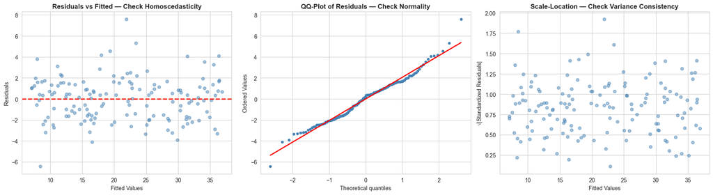

```
Interview key: Random scatter in residual plot = good model assumptions!
Patterns/funnel shapes = violated assumptions (heteroscedasticity, nonlinearity)
```

```python
# ──────────────────────────────────────────────
# Regression Diagnostics — Residual Plots
# ──────────────────────────────────────────────
import numpy as np
import matplotlib.pyplot as plt
from scipy import stats
from sklearn.linear_model import LinearRegression

np.random.seed(42)
X = np.random.uniform(0, 10, 150).reshape(-1, 1)
y = 3 * X.ravel() + 7 + np.random.normal(0, 2, 150)

model = LinearRegression().fit(X, y)
y_pred = model.predict(X)
residuals = y - y_pred

fig, axes = plt.subplots(1, 3, figsize=(18, 5))

# 1. Residuals vs Fitted
axes[0].scatter(y_pred, residuals, alpha=0.5, color='steelblue', s=30)
axes[0].axhline(y=0, color='red', linestyle='--', linewidth=2)
axes[0].set_xlabel('Fitted Values')
axes[0].set_ylabel('Residuals')
axes[0].set_title('Residuals vs Fitted — Check Homoscedasticity', fontweight='bold')

# 2. Normal QQ plot of residuals
stats.probplot(residuals, plot=axes[1])
axes[1].set_title('QQ-Plot of Residuals — Check Normality', fontweight='bold')
axes[1].get_lines()[0].set(color='steelblue', markersize=4)
axes[1].get_lines()[1].set(color='red', linewidth=2)

# 3. Scale-Location
std_resid = np.sqrt(np.abs(residuals / residuals.std()))
axes[2].scatter(y_pred, std_resid, alpha=0.5, color='steelblue', s=30)
axes[2].set_xlabel('Fitted Values')
axes[2].set_ylabel('√|Standardized Residuals|')
axes[2].set_title('Scale-Location — Check Variance Consistency', fontweight='bold')

plt.tight_layout()
plt.show()
print('Interview key: Random scatter in residual plot = good model assumptions!')
print('Patterns/funnel shapes = violated assumptions (heteroscedasticity, nonlinearity)')
```

#### Bias-Variance Tradeoff

$$\text{Total Error} = \text{Bias}^2 + \text{Variance} + \text{Irreducible Noise}$$

|  | High Bias | High Variance |
| --- | --- | --- |
| **Name** | Underfitting | Overfitting |
| **Train error** | High | Low |
| **Test error** | High | High |
| **Model** | Too simple (linear for non-linear data) | Too complex (degree-20 polynomial) |
| **Fix** | More features, complex model, less regularization | More data, simpler model, more regularization |

#### Regression — Interview Questions

| # | Question | Answer |
| --- | --- | --- |
| 1 | What are the assumptions of linear regression? | • **LINE**: Linearity, Independence, Normality of residuals, Equal variance • Also: no perfect multicollinearity, no influential outliers • Check with: residual plots, Shapiro-Wilk, Durbin-Watson, VIF… |
| 2 | What is R² and how do you interpret it? | • Proportion of variance in y explained by the model • R² = 0.75 → model explains 75% of variation in y • R² = 0: model no better than predicting mean • Caution: R² can be misleading for non-linear re… |
| 3 | Why use Adjusted R² instead of R²? | • R² never decreases when you add predictors (even useless ones) • Adjusted R² penalizes for each added predictor • Decreases if new variable doesn't help enough • Better for comparing models with dif… |
| 4 | What is heteroscedasticity? How do you detect and fix it? | • Residual variance changes with fitted values (funnel shape) • Detect: residuals vs fitted plot, Breusch-Pagan test, White test • Fix: log-transform y, use weighted least squares (WLS), robust SE • C… |
| 5 | What is the difference between Ridge and Lasso regression? | • Ridge (L2): shrinks all coefficients, none to zero — good for multicollinearity • Lasso (L1): shrinks some to exactly zero — automatic feature selection • Ridge better when many small effects; Lasso… |
| 6 | What is OLS? How does it estimate coefficients? | • Ordinary Least Squares: minimizes $\sum(y_i - \hat{y}_i)^2$ • Solution: $\hat{\beta} = (X^TX)^{-1}X^Ty$ • Makes error sum as small as possible • Gauss-Markov: OLS is BLUE (Best Linear Unbiased Estim… |
| 7 | What is the Gauss-Markov theorem? | • Under LINE assumptions, OLS estimator is BLUE: • Best = minimum variance; Linear = linear function of y; Unbiased = E[β̂]=β; Estimator • No other linear unbiased estimator has smaller variance • Doe… |
| 8 | How do you interpret coefficients in multiple regression? | • $\beta_j$: change in y for 1-unit change in $x_j$, holding all other x constant • 'Holding constant' = controlling/adjusting for other variables • Different from simple regression coefficients (Simp… |
| 9 | What is Cook's distance? | • Measures influence of each observation on the regression • Cook's D > 1: observation has disproportionate influence • High D: point is outlier AND high leverage • Action: investigate → is it data er… |
| 10 | What is the difference between interpolation and extrapolation? | • Interpolation: predict within range of training data — reliable • Extrapolation: predict outside range — risky, model may not hold • Linear model can work for interpolation but fail for extrapolatio… |
| 11 | What causes overfitting in regression? | • Too many predictors relative to observations (p close to n) • Complex model (high-degree polynomial) for simple relationship • Not using regularization • Fix: cross-validation, Ridge/Lasso, feature … |
| 12 | What is polynomial regression? | • $\hat{y} = \beta_0 + \beta_1 x + \beta_2 x^2 + \ldots + \beta_d x^d$ • Still linear in parameters (linear regression with polynomial features) • Higher degree: more flexible but risks overfitting • … |
| 13 | What is a residual? Why do we analyze residuals? | • $e_i = y_i - \hat{y}_i$ (observed minus predicted) • Residuals should be: random, normally distributed, constant variance, independent • Patterns in residuals reveal assumption violations • They're … |
| 14 | Explain the F-test in regression. | • Tests overall model significance: are ANY predictors useful? • H₀: all regression coefficients = 0 (model is useless) • $F = (R^2/p) / ((1-R^2)/(n-p-1))$ • Large F → model explains significant varia… |
| 15 | What is multicollinearity and how does it affect regression? | • Predictors are highly correlated with each other • Doesn't affect R² or predictions much • BUT: inflates SE of coefficients → unstable, unreliable individual β values • Detect: VIF > 5-10; Fix: remo… |
| 16 | What is weighted least squares (WLS)? | • Each observation gets a weight in the loss function: $\sum w_i(y_i - \hat{y}_i)^2$ • Down-weight observations with high variance (heteroscedastic) • Use when variance is proportional to a known func… |
| 17 | What is the difference between prediction interval and confidence interval? | • CI for E[y]: range for the AVERAGE response at given x — narrower • PI for y: range for an INDIVIDUAL observation at given x — wider • PI includes both estimation uncertainty + individual variation … |
| 18 | When would you use logistic regression instead of linear? | • When y is binary (0/1): click/no click, churn/no churn • Linear regression can predict outside [0,1] — problematic for probabilities • Logistic uses sigmoid: $P(y=1) = 1/(1+e^{-(\beta_0+\beta_1 x)})… |
| 19 | What is feature selection in regression? | • Choosing subset of predictors that best explain y • Methods: stepwise (forward/backward), Lasso (L1), information criteria (AIC/BIC) • AIC: $-2\ln(L) + 2p$; BIC: $-2\ln(L) + p\ln(n)$ (BIC penalizes … |
| 20 | What is the difference between R² and correlation coefficient r? | • For simple regression: $R^2 = r^2$ • r indicates direction (+/−); R² is always positive • For multiple regression: R² doesn't have a simple r equivalent • r is for bivariate relationships; R² for ov… |
| 21 | What is heteroscedasticity-consistent standard errors (robust SE)? | • SEs that are valid even under heteroscedasticity • Don't change coefficient estimates, only the SEs and p-values • HC0, HC1, HC2, HC3 variants (HC3 most common) • Often used as default in modern pra… |
| 22 | Explain AIC vs BIC for model selection. | • AIC: $-2\ln(L) + 2p$ — trade off fit vs complexity • BIC: $-2\ln(L) + p\ln(n)$ — heavier penalty for more parameters • BIC: more conservative, prefers simpler models • Use AIC for prediction focus; … |
| 23 | What is endogeneity? | • Correlation between predictor and error term ($\text{Cov}(x, \varepsilon) \neq 0$) • Causes: omitted variable bias, measurement error, simultaneity • OLS becomes biased and inconsistent • Fix: instr… |
| 24 | What is omitted variable bias? | • Leaving out a variable that affects both x and y • Causes coefficient of included variable to be biased • Direction depends on correlation between omitted and included variables • Example: regress s… |
| 25 | Explain interaction terms in regression. | • $\hat{y} = \beta_0 + \beta_1 x_1 + \beta_2 x_2 + \beta_3 x_1 x_2$ • $\beta_3$: effect of $x_1$ on y depends on level of $x_2$ • Example: drug effect differs by gender (drug × gender interaction) • A… |
| 26 | Walk through building a regression model from scratch. | • 1. EDA: scatter plots, correlations, distributions • 2. Split train/test (80/20 or cross-validation) • 3. Fit model, check R², coefficients, p-values • 4. Diagnostics: residual plots, VIF, Cook's di… |
| 27 | What is stepwise regression and its drawbacks? | • Forward: start empty, add best predictor one at a time • Backward: start full, remove worst predictor one at a time • Drawbacks: inflated Type I errors, multiple comparison issue, unstable • Better:… |
| 28 | What is a dummy variable trap? | • Including n dummy variables for n categories → perfect multicollinearity • One category is linearly dependent on the others • Fix: use n−1 dummies (drop one as reference category) • Or: use software… |
| 29 | What is leverage in regression? | • How far an observation's x-values are from the center • High leverage point CAN influence the regression line dramatically • Leverage without large residual → no problem • High leverage + large resi… |
| 30 | What is robust regression? | • Methods that resist outlier influence: RANSAC, Huber, bisquare • M-estimators: minimize ρ(residual) instead of squared residual • Breakdown point: % of outliers before estimator fails (median: 50%; … |